# Case Study: Reddit Social Network Analysis Against Influence Operation

Adel Abu Hashim, David Yacoup & Mahmoud Nagy - August 2021

[figure not shown]

- Introduction
- Data Wrangling
- Data Cleaning
- Exploratory Data Analysis
- Conclusions

## Introduction

> This case study aims to help **Amber Heard**

> By analyzing new accounts posting/ commenting against a victim of a Social Bot Disinformation/Influence Operation.

> **We have three main datasets**:  
> (The datasets screaped from **reddit**).
> - 1- A dataset with submissions & comments data (2018).
> - 2- Users Data (from 2006 to 2021)
> - 3- Daily creation data (# of accounts created per day from 2006 to 2021)

```python
#import dependencies
import numpy as np
import pandas as pd
import matplotlib.pyplot as plt
import seaborn as sns
import os
import glob
import helpers
import matplotlib.dates as mdates
import plotly.express as px
import re
sns.set_style("darkgrid")
%matplotlib inline
```

```python
# load data into DataFrames
df = pd.read_csv("reddit_2018.csv")
print(df.shape)
df.head()
```

```
(6993, 15)
```

|  | _index | _type | _id | _score | id | name | permalink | text | parent_id | subreddit | author | created_at | entities.urls | sentiment_blob | sentiment_nltk |
| --- | --- | --- | --- | --- | --- | --- | --- | --- | --- | --- | --- | --- | --- | --- | --- |
| 0 | reddit | _doc | XFnTbHoBZsCJ_ScUYVzY | 1.0 | 7u8w98 | t3_7u8w98 | /r/CelebrityArmpits/comments/7u8w98/amber_heard_aic/ | Amber Heard [AIC] | NaN | r/CelebrityArmpits | pitsnbush | Wed Jan 31 10:05:02 +0000 2018 | [] | Neutral | Neutral |
| 1 | reddit | _doc | XVnTbHoBZsCJ_ScUZFx9 | 1.0 | 7u8r8q | t3_7u8r8q | /r/JerkOffToCelebs/comments/7u8r8q/amber_heard_hot_bod/ | Amber Heard Hot Bod | NaN | r/JerkOffToCelebs | -banned- | Wed Jan 31 09:31:10 +0000 2018 | [] | Positive | Neutral |
| 2 | reddit | _doc | XlnTbHoBZsCJ_ScUaVxJ | 1.0 | 7u8rhp | t3_7u8rhp | /r/celebritystockings/comments/7u8rhp/amber_heard/ | Amber Heard | NaN | r/celebritystockings | -banned- | Wed Jan 31 09:32:51 +0000 2018 | [] | Neutral | Neutral |
| 3 | reddit | _doc | YFnTbHoBZsCJ_ScUc1wa | 1.0 | 7u4bxm | t3_7u4bxm | /r/sexygirls/comments/7u4bxm/amber_heard/ | Amber Heard | NaN | r/sexygirls | -banned- | Tue Jan 30 21:09:11 +0000 2018 | [] | Neutral | Neutral |
| 4 | reddit | _doc | YVnTbHoBZsCJ_ScUd1y5 | 1.0 | 7u8o8x | t3_7u8o8x | /r/celebritystockings/comments/7u8o8x/amber_heard/ | Amber Heard | NaN | r/celebritystockings | -banned- | Wed Jan 31 09:10:27 +0000 2018 | [] | Neutral | Neutral |

```python
# merging all users_created as one dataframe "df_users"
df_users = pd.concat(map(pd.read_csv, glob.glob(os.path.join('', "./user_data/*.csv"))))
print(df_users.shape)
df_users
```

```
(50566, 6)
```

|  | author.name | author.created_at | author.has_verified_email | author.is_employee | author.is_mod | author.is_gold |
| --- | --- | --- | --- | --- | --- | --- |
| 0 | cozixemera | 2018-01-13 16:26:14+00:00 | False | False | False | False |
| 1 | iplayinv3rtd | 2018-02-04 22:47:06+00:00 | True | False | False | False |
| 2 | devindub | 2018-02-14 03:47:09+00:00 | False | False | True | False |
| 3 | SilviaJu | 2018-02-14 03:47:09+00:00 | False | False | True | False |
| 4 | hk8842138 | 2018-02-06 12:13:04+00:00 | True | False | False | False |
| ... | ... | ... | ... | ... | ... | ... |
| 5681 | LaBabadook | 2016-11-12 21:45:46+00:00 | True | False | False | True |
| 5682 | Rapturesjoy | 2016-11-12 21:45:46+00:00 | True | False | False | True |
| 5683 | KingDongBundy | 2016-10-10 00:01:25+00:00 | True | False | False | False |
| 5684 | TypingWithIntent | 2016-10-10 00:01:25+00:00 | True | False | False | False |
| 5685 | porousasshole | 2016-01-26 02:48:25+00:00 | True | False | True | False |

50566 rows × 6 columns

```python
# merging all daily_creations as one dataframe "daily_creations"

df_daily_creation = pd.concat(map(pd.read_csv, glob.glob(os.path.join('', "./daily_creation/*.csv"))))

# Convert the date column to datetime format
df_daily_creation['author.created_at'] = pd.to_datetime(df_daily_creation['author.created_at'],format='%Y-%m-%d %H:%M:%S+00:00')
# sorting the dataframe in date order
df_daily_creation.sort_values(by='author.created_at', inplace=True)

print(df_daily_creation.shape)
df_daily_creation
```

```
(5101, 2)
```

|  | author.created_at | author.name |
| --- | --- | --- |
| 0 | 2006-01-05 | 1 |
| 1 | 2006-01-06 | 0 |
| 2 | 2006-01-07 | 0 |
| 3 | 2006-01-08 | 0 |
| 4 | 2006-01-09 | 0 |
| ... | ... | ... |
| 143 | 2021-05-24 | 0 |
| 144 | 2021-05-25 | 0 |
| 145 | 2021-05-26 | 0 |
| 146 | 2021-05-27 | 0 |
| 147 | 2021-05-28 | 1 |

5101 rows × 2 columns

###### Now, We have 3 dataframes:

- **df** (reddit submissions/comments for 2018).
- **df_users** (Users Data from 2006 to 2021.
- **df_daily_creation** (# of accounts created per day from 2006 to 2021).

## Data Wrangling

- Introduction
- **Data Wrangling**
- Data Cleaning
- Exploratory Data Analysis
- Conclusions

### General Properties

### df (2018)

```python
#print the shape & first row of df
print(df.shape)
df.head(1)
```

```
(6993, 15)
```

|  | _index | _type | _id | _score | id | name | permalink | text | parent_id | subreddit | author | created_at | entities.urls | sentiment_blob | sentiment_nltk |
| --- | --- | --- | --- | --- | --- | --- | --- | --- | --- | --- | --- | --- | --- | --- | --- |
| 0 | reddit | _doc | XFnTbHoBZsCJ_ScUYVzY | 1.0 | 7u8w98 | t3_7u8w98 | /r/CelebrityArmpits/comments/7u8w98/amber_heard_aic/ | Amber Heard [AIC] | NaN | r/CelebrityArmpits | pitsnbush | Wed Jan 31 10:05:02 +0000 2018 | [] | Neutral | Neutral |

```python
#print df's statiscs
df.describe()
```

|  | _score |
| --- | --- |
| count | 6993.0 |
| mean | 1.0 |
| std | 0.0 |
| min | 1.0 |
| 25% | 1.0 |
| 50% | 1.0 |
| 75% | 1.0 |
| max | 1.0 |

the results due one column **_score**, it is the only numeric one, we will see this in dtypes part

```python
# unique values of _score column
df._score.unique()
```

```
array([1.])
```

we have only one value 1 so it is obvious now why all statistics are 1 and std is 0.  
_score should be deleted

```python
list_columns_to_drop_df = ['_score']
```

```python
# dataframe info
df.info()
```

```
<class 'pandas.core.frame.DataFrame'>
RangeIndex: 6993 entries, 0 to 6992
Data columns (total 15 columns):
 #   Column          Non-Null Count  Dtype
---  ------          --------------  -----
 0   _index          6993 non-null   object
 1   _type           6993 non-null   object
 2   _id             6993 non-null   object
 3   _score          6993 non-null   float64
 4   id              6993 non-null   object
 5   name            6993 non-null   object
 6   permalink       6993 non-null   object
 7   text            6993 non-null   object
 8   parent_id       4993 non-null   object
 9   subreddit       6993 non-null   object
 10  author          6993 non-null   object
 11  created_at      6993 non-null   object
 12  entities.urls   6993 non-null   object
 13  sentiment_blob  6993 non-null   object
 14  sentiment_nltk  6993 non-null   object
dtypes: float64(1), object(14)
memory usage: 819.6+ KB
```

we have only one column **parent_id** that has nulls

```python
# print columns data types
helpers.object_dtype(df)
```

```
_index <class 'str'>
_type <class 'str'>
_id <class 'str'>
id <class 'str'>
name <class 'str'>
permalink <class 'str'>
text <class 'str'>
parent_id <class 'float'>
subreddit <class 'str'>
author <class 'str'>
created_at <class 'str'>
entities.urls <class 'str'>
sentiment_blob <class 'str'>
sentiment_nltk <class 'str'>
```

```python
# show unique value of each column; as we can know the right data type
for column in df.select_dtypes(include=['object']).columns:
    print(column)
    print(df[column].unique())
```

```
_index
['reddit']
_type
['_doc']
_id
['XFnTbHoBZsCJ_ScUYVzY' 'XVnTbHoBZsCJ_ScUZFx9' 'XlnTbHoBZsCJ_ScUaVxJ' ...
 'u1mebHoBZsCJ_ScUB0n-' 'IVmebHoBZsCJ_ScU60pg' 'pFmgbHoBZsCJ_ScUX0qj']
id
['7u8w98' '7u8r8q' '7u8rhp' ... 'ebd4tah' 'ecvwhd2' 'ebtnfz3']
name
['t3_7u8w98' 't3_7u8r8q' 't3_7u8rhp' ... 't1_ebd4tah' 't1_ecvwhd2'
 't1_ebtnfz3']
permalink
['/r/CelebrityArmpits/comments/7u8w98/amber_heard_aic/'
 '/r/JerkOffToCelebs/comments/7u8r8q/amber_heard_hot_bod/'
 '/r/celebritystockings/comments/7u8rhp/amber_heard/' ...
 '/r/coatswithoutshirts/comments/9wd40o/amber_heard/ebd4tah/'
 '/r/Celebsnudess/comments/9v5q2b/amber_heard_london_fields_2018/ecvwhd2/'
 '/r/pickoneceleb/comments/9thl3q/women_of_dc_redhead_vs_blonde_vs_brunette_amy/ebtnfz3/']
text
['Amber Heard [AIC]' 'Amber Heard Hot Bod' 'Amber Heard' ...
 "Actually... they aren't sharks, they are creatures of the trench"
 "Now that's a woman I'd love to plow"
 "Bedroom. Amy Adams; a spiteful choice, since she's the same age my wife is, but supernaturally hotter, with tits 7× tastier\n\nRed Carpet. Amy also, I'm assuming the malfunction deals with tits showing...I'd cum in her throat, while gripping those giant tits tight. \n\nIn costume. Gal. I'd make he…
parent_id
[nan 't3_7sgl66' 't1_dt561qg' ... 't1_easxyfi' 't3_a21gil' 't3_9v5q2b']
subreddit
['r/CelebrityArmpits' 'r/JerkOffToCelebs' 'r/celebritystockings'
 'r/sexygirls' 'r/FleshyArmpits' 'r/CelebrityFeet' 'r/celebritylegs'
 'r/DCEUboners' 'r/gentlemanboners' 'r/goddesses' 'r/MovieSuggestions'
 'r/PrettyGirls' 'r/Celebs' 'r/dirtypenpals' 'r/iWantToFuckHer'
 'r/elonmusk' 'r/news' 'r/celebrity' 'r/SubredditDrama' 'r/Celeb_Collages'
 'r/pics' 'r/CelebrityTongues' 'r/newstweetfeed' 'u/NeverOwnedAnyone'
 'r/MensRights' 'r/Elon_musketeers' 'r/AskMen' 'r/PNNBPS'
 'r/BeautifulFemales' 'r/gentlemanbonersgifs' 'r/WtSSTaDaMiT'
 'r/SexyWomanOfTheDay' 'r/Amber_Heard' 'r/HighHeels' 'r/celebnsfw'
 'r/celebheels' 'r/movies' 'r/celebJObuds' 'r/todayilearned' 'r/sketches'
 'r/nsfwasmr' 'r/DC_Cinematic' 'r/moviescirclejerk' 'r/REEEEEEEEEE'
 'r/HighResCelebs' 'r/WatchItForThePlot' 'r/REPORT_ITALIANO'
 'r/Hot_Women_Gifs' 'r/GirlsLaughing' 'r/OnOffCelebs' 'r/crossedlegs'
```

[output cut: 171 more lines]

```
 "[{'display_url': 'https://www.theguardian.com'}]"
 "[{'display_url': 'http://www.wolframalpha.com'}, {'display_url': 'https://www.reddit.com'}, {'display_url': 'http://np.reddit.com'}, {'display_url': 'https://www.reddit.com'}, {'display_url': 'http://np.reddit.com'}, {'display_url': 'http://np.reddit.com'}, {'display_url': 'http://np.reddit.com'},…
 "[{'display_url': 'https://www.foxnews.com'}]"
 "[{'display_url': 'https://www.imdb.com'}]"
 "[{'display_url': 'https://www.instagram.com'}]"
 "[{'display_url': 'https://akns-images.eonline.com'}]"
 "[{'display_url': 'https://i.imgur.com'}, {'display_url': 'https://i.imgur.com'}, {'display_url': 'https://i.imgur.com'}, {'display_url': 'https://i.imgur.com'}]"
 "[{'display_url': 'https://66.media.tumblr.com'}, {'display_url': 'https://66.media.tumblr.com'}, {'display_url': 'https://github.com'}, {'display_url': 'http://www.reddit.com'}]"
 "[{'display_url': 'https://www.writeups.org'}, {'display_url': 'http://3.bp.blogspot.com'}]"
 "[{'display_url': 'https://www.thenipslip.com'}]"
 "[{'display_url': 'https://ew.com'}]"]
sentiment_blob
['Neutral' 'Positive' 'Negative']
sentiment_nltk
['Neutral' 'Negative' 'Positive']
```

_index and _type also should be deleted

```python
list_columns_to_drop_df.append('_index')
list_columns_to_drop_df.append('_type')
```

### df_users

```python
#print the first row of df
df_users.head(1)
```

|  | author.name | author.created_at | author.has_verified_email | author.is_employee | author.is_mod | author.is_gold |
| --- | --- | --- | --- | --- | --- | --- |
| 0 | cozixemera | 2018-01-13 16:26:14+00:00 | False | False | False | False |

The data looks good!  
only **author.created_at** needs to be in right format.

```python
#df shape
helpers.df_shape(df_users)
```

```
the df has 50566 rows and 6 columns
```

```python
#print df's statiscs
df_users.describe()
```

|  | author.name | author.created_at | author.has_verified_email | author.is_employee | author.is_mod | author.is_gold |
| --- | --- | --- | --- | --- | --- | --- |
| count | 50566 | 50566 | 50542 | 50566 | 50566 | 50566 |
| unique | 50566 | 3464 | 2 | 1 | 2 | 2 |
| top | SmokyDragonDish | 2019-07-27 01:15:02+00:00 | True | False | False | False |
| freq | 1 | 4178 | 43158 | 50566 | 31780 | 46049 |

we have 50566 records,  
something weired in **author.is_employee**; 1 unique value?!

```python
# unique values of author.is_employee column
df_users['author.is_employee'].unique()
```

```
array([False])
```

author.is_employee should be dropped

```python
list_columns_to_drop_users = ['author.is_employee']
```

```python
# dataframe info
df_users.info()
```

```
<class 'pandas.core.frame.DataFrame'>
Int64Index: 50566 entries, 0 to 5685
Data columns (total 6 columns):
 #   Column                     Non-Null Count  Dtype
---  ------                     --------------  -----
 0   author.name                50566 non-null  object
 1   author.created_at          50566 non-null  object
 2   author.has_verified_email  50542 non-null  object
 3   author.is_employee         50566 non-null  bool
 4   author.is_mod              50566 non-null  bool
 5   author.is_gold             50566 non-null  bool
dtypes: bool(3), object(3)
memory usage: 1.7+ MB
```

```python
# check author.has_verified_email data type
type(df_users['author.has_verified_email'][0])
```

```
pandas.core.series.Series
```

### df_daily_creation

```python
#print the first row of df
df_daily_creation.head(1)
```

|  | author.created_at | author.name |
| --- | --- | --- |
| 0 | 2006-01-05 | 1 |

**author.created_at** needs to be in right format.

```python
#df shape
helpers.df_shape(df_daily_creation)
```

```
the df has 5101 rows and 2 columns
```

```python
#print df's statiscs
df_daily_creation.describe()
```

|  | author.name |
| --- | --- |
| count | 5101.000000 |
| mean | 9.912958 |
| std | 85.126357 |
| min | 0.000000 |
| 25% | 0.000000 |
| 50% | 0.000000 |
| 75% | 2.000000 |
| max | 4185.000000 |

```python
# unique values of author.name column
df_daily_creation['author.name'].unique()
```

```
array([   1,    0,    8,    2,    4,   17,    3,   12,   14,   32,   74,
         31,  200,    5,    9,   10,  191,   57,   21,  144,   19,   20,
         28,   35,   50,  412,   11,   65,   63,   80,   22,   36,    7,
          6,   72,   13,   18,   24,   16,   88,  282,  180,   15,  106,
         40,   39,   38,   37,  188,  722,   64,   26,  199,  269,   27,
         53, 2412,  241,   73,   30,   43,   33,   66,  414,   75,   44,
        123,  367,  132,   83,  164,  142,  171,  347,  166,   62,   46,
        102,  133,   60,  158,   34,  111,   70,   29,   54,   56,   25,
         76,  219,  304,   23,  172,  437,  287,  608,  141,  163,  570,
        806,  115, 1115,   84, 1221,   42,  343,   68,  465,  150,   82,
         45,  506,   95,   55,  519,   58,   41,   94,  125,   87, 1105,
         51,   99,  101,   85,  155,   79,  201,   48,  143,  104,  100,
        167,  160,  689,   59,  137,  112, 4185,  360,   49,  318, 1547,
        441,   47,   67,  113,  430,  185,  350,  103,   71,  609,   89,
         77,  309,  108,  344,   86,  126])
```

**author.name** needs to be renamed.

# Data Cleaning

- Introduction
- Data Wrangling
- **Data Cleaning**
- Exploratory Data Analysis
- Conclusions
- 2018 Data
- Users Data
- Daily Creation Data

```python
# make a copies from 3 data sets to be cleaned
df_cleaned = df.copy()
df_users_cleaned = df_users.copy()
df_daily_creation_cleaned = df_daily_creation.copy()
```

### df (2018)

### Fixing data types

```python
# date column
df_cleaned['created_at'] = pd.to_datetime(df_cleaned['created_at'], format='%a %b %d %H:%M:%S +0000 %Y')
```

```python
type(df_cleaned['created_at'][0])
```

```
pandas._libs.tslibs.timestamps.Timestamp
```

### Drop Extraneous columns

```python
df_cleaned.columns
```

```
Index(['_index', '_type', '_id', '_score', 'id', 'name', 'permalink', 'text',
       'parent_id', 'subreddit', 'author', 'created_at', 'entities.urls',
       'sentiment_blob', 'sentiment_nltk'],
      dtype='object')
```

```python
# drop also the id and _id columns since we are not gonna use in our analysis
list_columns_to_drop_df.append('_id')
list_columns_to_drop_df.append('id')
```

```python
df_cleaned.drop(columns= list_columns_to_drop_df, inplace=True)
```

```python
df_cleaned.head(2)
```

|  | name | permalink | text | parent_id | subreddit | author | created_at | entities.urls | sentiment_blob | sentiment_nltk |
| --- | --- | --- | --- | --- | --- | --- | --- | --- | --- | --- |
| 0 | t3_7u8w98 | /r/CelebrityArmpits/comments/7u8w98/amber_heard_aic/ | Amber Heard [AIC] | NaN | r/CelebrityArmpits | pitsnbush | 2018-01-31 10:05:02 | [] | Neutral | Neutral |
| 1 | t3_7u8r8q | /r/JerkOffToCelebs/comments/7u8r8q/amber_heard_hot_bod/ | Amber Heard Hot Bod | NaN | r/JerkOffToCelebs | -banned- | 2018-01-31 09:31:10 | [] | Positive | Neutral |

### df_users

### Fixing data types

```python
df_users_cleaned.columns
```

```
Index(['author.name', 'author.created_at', 'author.has_verified_email',
       'author.is_employee', 'author.is_mod', 'author.is_gold'],
      dtype='object')
```

```python
# date column
df_users_cleaned['author.created_at'] = pd.to_datetime(df_users_cleaned['author.created_at'],format='%Y-%m-%d %H:%M:%S+00:00')
```

```python
df_users_cleaned.head(2)
```

|  | author.name | author.created_at | author.has_verified_email | author.is_employee | author.is_mod | author.is_gold |
| --- | --- | --- | --- | --- | --- | --- |
| 0 | cozixemera | 2018-01-13 16:26:14 | False | False | False | False |
| 1 | iplayinv3rtd | 2018-02-04 22:47:06 | True | False | False | False |

### Drop Extraneous columns

```python
df_users_cleaned.drop(columns= list_columns_to_drop_users, inplace=True)
```

```python
df_users_cleaned.head(2)
```

|  | author.name | author.created_at | author.has_verified_email | author.is_mod | author.is_gold |
| --- | --- | --- | --- | --- | --- |
| 0 | cozixemera | 2018-01-13 16:26:14 | False | False | False |
| 1 | iplayinv3rtd | 2018-02-04 22:47:06 | True | False | False |

### df_daily_creation

### Fixing data types

```python
df_daily_creation_cleaned.columns
```

```
Index(['author.created_at', 'author.name'], dtype='object')
```

```python
# date column
df_daily_creation_cleaned['author.created_at'] = pd.to_datetime(df_daily_creation_cleaned['author.created_at'],format='%Y-%m-%d %H:%M:%S+00:00')
```

```python
df_daily_creation_cleaned.head(2)
```

|  | author.created_at | author.name |
| --- | --- | --- |
| 0 | 2006-01-05 | 1 |
| 1 | 2006-01-06 | 0 |

### Rename columns

```python
df_daily_creation_cleaned.columns = ['created_at', 'n_accounts']
```

```python
df_daily_creation_cleaned.head(2)
```

|  | created_at | n_accounts |
| --- | --- | --- |
| 0 | 2006-01-05 | 1 |
| 1 | 2006-01-06 | 0 |

## Exploratory Data Analysis

- Introduction
- Data Wrangling
- Data Cleaning
- **Exploratory Data Analysis**
- Conclusions
- **Daily Creation Data**
- User Charcterstics
- Reddit Comments/Submissions Data
- Merged Users Data with Comments/Submissions Data

### Exploring Daily Creation Data

### Estimation of the number of user accounts created in each year

```python
# extract year from date
df_daily_creation_cleaned['creation_year'] = df_daily_creation_cleaned['created_at'].dt.year
```

```python
df_daily_creation_cleaned.groupby('creation_year').sum('n_accounts').reset_index()
```

|  | creation_year | n_accounts |
| --- | --- | --- |
| 0 | 2006 | 13 |
| 1 | 2007 | 21 |
| 2 | 2008 | 49 |
| 3 | 2009 | 172 |
| 4 | 2010 | 263 |
| 5 | 2011 | 602 |
| 6 | 2012 | 1026 |
| 7 | 2013 | 2550 |
| 8 | 2014 | 4408 |
| 9 | 2015 | 2595 |
| 10 | 2016 | 5686 |
| 11 | 2017 | 5984 |
| 12 | 2018 | 5884 |
| 13 | 2019 | 13145 |
| 14 | 2020 | 7729 |
| 15 | 2021 | 439 |

```python
fig = px.bar(df_daily_creation_cleaned.groupby('creation_year').sum('n_accounts').reset_index(),
             x='creation_year', y='n_accounts', text='n_accounts')
fig.update_traces(marker_color='#f69c56',
                  marker_line_width=1.5, opacity=1, textposition='auto')
fig.show()
```

[interactive chart not shown]

##### the effect of 2019 and 2020 data is obvious, what about 2021?

```python
df_daily_creation_cleaned.tail(5)
```

|  | created_at | n_accounts | creation_year |
| --- | --- | --- | --- |
| 143 | 2021-05-24 | 0 | 2021 |
| 144 | 2021-05-25 | 0 | 2021 |
| 145 | 2021-05-26 | 0 | 2021 |
| 146 | 2021-05-27 | 0 | 2021 |
| 147 | 2021-05-28 | 1 | 2021 |

#### yes, as expected, the data of 2021 is not complete, till may only.

```python
# filter on years with peaks (2019, 2020, 2021)
df_creation_temp = df_daily_creation_cleaned[(df_daily_creation_cleaned['creation_year'] == 2019) |
                         (df_daily_creation_cleaned['creation_year'] == 2020) |
                         (df_daily_creation_cleaned['creation_year'] == 2021)][['created_at', 'n_accounts']]
```

```python
# filter on years with peaks (2019, 2020, 2021)
df_creation_temp
```

|  | created_at | n_accounts |
| --- | --- | --- |
| 0 | 2019-01-01 | 7 |
| 1 | 2019-01-02 | 3 |
| 2 | 2019-01-03 | 64 |
| 3 | 2019-01-04 | 16 |
| 4 | 2019-01-05 | 85 |
| ... | ... | ... |
| 143 | 2021-05-24 | 0 |
| 144 | 2021-05-25 | 0 |
| 145 | 2021-05-26 | 0 |
| 146 | 2021-05-27 | 0 |
| 147 | 2021-05-28 | 1 |

879 rows × 2 columns

```python
fig = px.bar(df_creation_temp,
             x='created_at',
             y='n_accounts')
fig.update_traces(marker_color='#f69c56', marker_line_color='#f69c56',
                  marker_line_width=2, opacity=1, textposition='auto')
fig.show()
```

[interactive chart not shown]

```python
fig = px.bar(df_daily_creation_cleaned,
             x='created_at', y='n_accounts')
fig.update_traces(marker_color='#f69c56', marker_line_color='#f69c56',
                  marker_line_width=2, opacity=1, textposition='auto')
fig.show()
```

[interactive chart not shown]

- Daily Creation Data
- **User Charcterstics**
- Reddit Comments/Submissions Data
- Merged Users Data with Comments/Submissions Data

### User Charcterstics

### Verified Mail

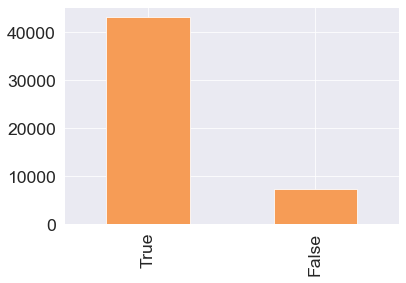

```python
df_users_cleaned['author.has_verified_email'].value_counts().plot(kind='bar', color='#f69c56');
```

##### verifying mail is not a mark that is the account is spam, as most of accounts has verified their mails

### Is Gold?

> > Gold is a way to show appreciation for an exceptional contribution to Reddit.

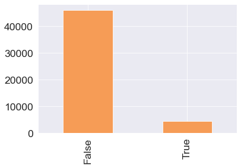

```python
df_users_cleaned['author.is_gold'].value_counts().plot(kind='bar', color='#f69c56');
```

##### No one would appretiate spammers!

### Is Mod?

> > Mod -> Moderator

A moderator, or a mod for short, are redditors who volunteer their time to help guide and create Reddit's many communities. Each Reddit community has its own focus, look, and rules, including what posts are on-topic there and how users are expected to behave. ... Add other redditors as moderators. https://www.reddit.com/r/help/comments/1f0zni/what_are_mods_for_and_what_are_their/

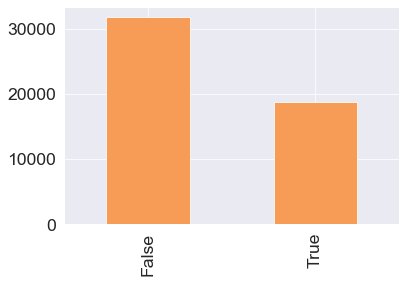

```python
df_users_cleaned['author.is_mod'].value_counts().plot(kind='bar', color='#f69c56');
```

```python
df_users_cleaned.groupby(df_users_cleaned['author.created_at'].dt.year).sum()
```

| author.created_at | author.is_mod | author.is_gold |
| --- | --- | --- |
| 2006 | 11 | 0 |
| 2007 | 21 | 0 |
| 2008 | 37 | 0 |
| 2009 | 47 | 31 |
| 2010 | 28 | 5 |
| 2011 | 163 | 58 |
| 2012 | 195 | 13 |
| 2013 | 1673 | 188 |
| 2014 | 2857 | 441 |
| 2015 | 1030 | 272 |
| 2016 | 1403 | 813 |
| 2017 | 3392 | 170 |
| 2018 | 2506 | 1703 |
| 2019 | 3266 | 746 |
| 2020 | 1942 | 76 |
| 2021 | 215 | 1 |

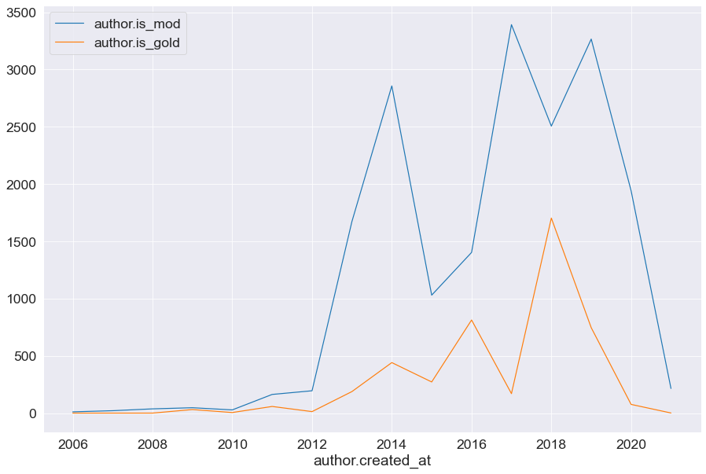

```python
df_users_cleaned.groupby(df_users_cleaned['author.created_at'].dt.year).sum().plot(figsize=(15,10));
```

```python
df_users_cleaned
```

|  | author.name | author.created_at | author.has_verified_email | author.is_mod | author.is_gold |
| --- | --- | --- | --- | --- | --- |
| 0 | cozixemera | 2018-01-13 16:26:14 | False | False | False |
| 1 | iplayinv3rtd | 2018-02-04 22:47:06 | True | False | False |
| 2 | devindub | 2018-02-14 03:47:09 | False | True | False |
| 3 | SilviaJu | 2018-02-14 03:47:09 | False | True | False |
| 4 | hk8842138 | 2018-02-06 12:13:04 | True | False | False |
| ... | ... | ... | ... | ... | ... |
| 5681 | LaBabadook | 2016-11-12 21:45:46 | True | False | True |
| 5682 | Rapturesjoy | 2016-11-12 21:45:46 | True | False | True |
| 5683 | KingDongBundy | 2016-10-10 00:01:25 | True | False | False |
| 5684 | TypingWithIntent | 2016-10-10 00:01:25 | True | False | False |
| 5685 | porousasshole | 2016-01-26 02:48:25 | True | True | False |

50566 rows × 5 columns

### Estimation of no. of user accounts created in all years

```python
user_accounts_count = df_users_cleaned.groupby(df_users_cleaned['author.created_at'].dt.year).size().reset_index(name='year_count')
user_accounts_count
```

|  | author.created_at | year_count |
| --- | --- | --- |
| 0 | 2006 | 13 |
| 1 | 2007 | 21 |
| 2 | 2008 | 49 |
| 3 | 2009 | 172 |
| 4 | 2010 | 263 |
| 5 | 2011 | 602 |
| 6 | 2012 | 1026 |
| 7 | 2013 | 2550 |
| 8 | 2014 | 4408 |
| 9 | 2015 | 2595 |
| 10 | 2016 | 5686 |
| 11 | 2017 | 5984 |
| 12 | 2018 | 5884 |
| 13 | 2019 | 13145 |
| 14 | 2020 | 7729 |
| 15 | 2021 | 439 |

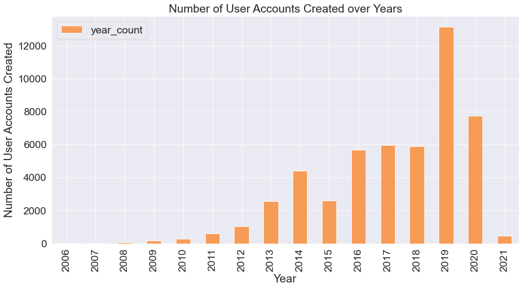

```python
user_accounts_count.plot(x="author.created_at", y="year_count", kind="bar", figsize=(14,7), color='#f69c56')
plt.xlabel('Year')
plt.ylabel('Number of User Accounts Created')
plt.title('Number of User Accounts Created over Years');
```

**NOTE:**  
Reddit began to achieve a notable level of popularity in mid-2010, and it has expanded its reach since. It had become “really popular” in early 2013.

Reddit was launched in June 2005

- Daily Creation Data
- User Charcterstics
- **Reddit Comments/Submissions Data**
- Merged Users Data with Comments/Submissions Data

### Reddit Comments/Submission Data

```python
def top_level(parent_id):
    if parent_id is not np.nan:
        if parent_id[:2] == 't3':
            return 'submission'
        elif parent_id[:2] == 't1':
            return 'comment'
        else:
            return np.nan
```

```python
sum(df_cleaned['parent_id'].isnull())
```

```
2000
```

2000 parent_id is null --> 2000 submissions

```python
df_cleaned['top_level'] = df_cleaned.parent_id.apply(top_level)
```

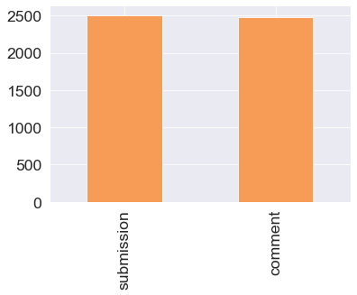

```python
df_cleaned['top_level'].value_counts().plot(kind='bar', color='#f69c56');
```

```python
def submission_comment(name):
    if name is not np.nan:
        if name.startswith('t3'):
            return 'submission'
        elif name.startswith('t1'):
            return 'comment'
        else:
            return np.nan
```

```python
sum(df_cleaned['name'].isnull())
```

```
0
```

```python
df_cleaned['submission_comment'] = df_cleaned.name.apply(submission_comment)
```

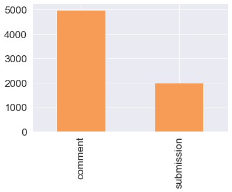

```python
df_cleaned['submission_comment'].value_counts().plot(kind='bar', color='#f69c56');
```

### NLTK vs BLOB clssification

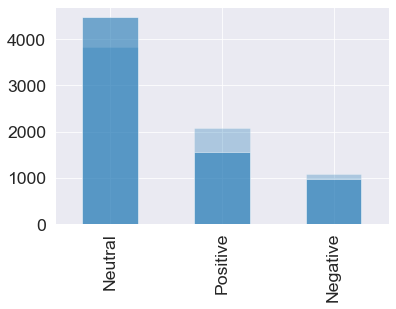

```python
df_cleaned.sentiment_blob.value_counts().plot(kind='bar', alpha = 0.3);
df_cleaned.sentiment_nltk.value_counts().plot(kind='bar', alpha = 0.6);
```

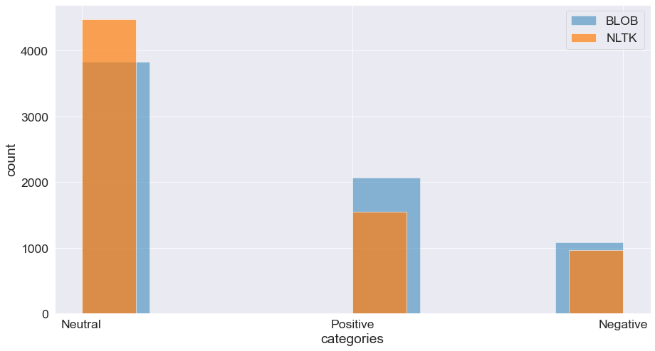

```python
fig , ax = plt.subplots(figsize = (15,8))
df_cleaned.sentiment_blob.hist(alpha = 0.5 , bins = 8 , label = 'BLOB')
df_cleaned.sentiment_nltk.hist(alpha = 0.7 , bins = 10 , label = 'NLTK')

plt.xlabel('categories');
plt.ylabel('count');
ax.legend();
```

```python
df_sentiment = pd.merge(df_cleaned.sentiment_nltk.value_counts().to_frame(),
        df_cleaned.sentiment_blob.value_counts().to_frame(),
        left_index=True, right_index=True)
print(df_sentiment)
```

```
          sentiment_nltk  sentiment_blob
Neutral             4478            3837
Positive            1548            2073
Negative             967            1083
```

https://stackoverflow.com/questions/27898830/python-how-to-change-autopct-text-color-to-be-white-in-a-pie-chart

https://stackoverflow.com/questions/31517194/how-to-hide-one-specific-cell-input-or-output-in-ipython-notebook

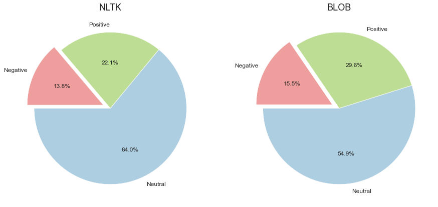

```python
explode = [0, 0, 0.1]

fig, (ax1, ax2) = plt.subplots(1, 2, figsize = (15,8))
ax1.pie(df_sentiment.sentiment_nltk,
        labels = df_sentiment.index,
        autopct='%1.1f%%',
        explode = explode,
        textprops={'fontsize': 12},
#         textprops={'color':"w"},
        colors = ['#adcde1', '#bcdd93', '#ee9e9c'],
        startangle=180)
ax2.pie(df_sentiment.sentiment_blob,
        labels = df_sentiment.index,
        colors = ['#adcde1', '#bcdd93', '#ee9e9c'],
        autopct='%1.1f%%',
        explode = explode,
        textprops={'fontsize': 12},
        startangle=180)
ax1.set_title('NLTK', fontdict = {'fontsize' : 18})
ax2.set_title('BLOB', fontdict = {'fontsize' : 18})
plt.show()
```

https://matplotlib.org/stable/tutorials/colors/colormaps.html

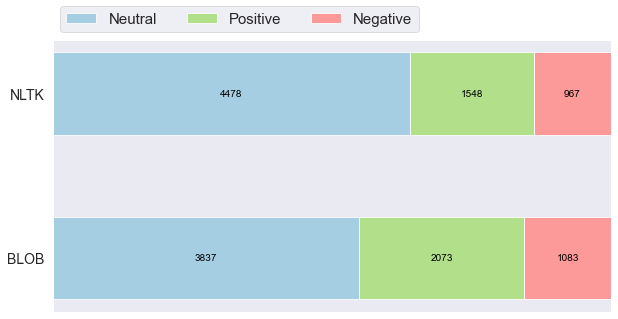

```python
category_names = df_sentiment.index
dict_models = {
    'NLTK': df_sentiment.sentiment_nltk,
    'BLOB': df_sentiment.sentiment_blob
}


def models(dict_models, category_names):

    labels = list(dict_models.keys())
    data = np.array(list(dict_models.values()))
    data_cum = data.cumsum(axis=1)
    category_colors = plt.get_cmap('Paired')(
        np.linspace(0.08, 0.40, data.shape[1]))

    fig, ax = plt.subplots(figsize=(10, 5))
    ax.invert_yaxis()
    ax.xaxis.set_visible(False)
    ax.set_xlim(0, np.sum(data, axis=1).max())

    for i, (colname, color) in enumerate(zip(category_names, category_colors)):
        widths = data[:, i]
        starts = data_cum[:, i] - widths
        ax.barh(labels, widths, left=starts, height=0.5,
                label=colname, color=color)
        xcenters = starts + widths / 2

        r, g, b, _ = color
        text_color = 'white' if r * g * b < 0.25 else 'black'
        for y, (x, c) in enumerate(zip(xcenters, widths)):
            ax.text(x, y, str(int(c)), ha='center', va='center',
                    color=text_color)
    ax.legend(ncol=len(category_names), bbox_to_anchor=(0, 1),
              loc='lower left', fontsize=15)
    ax.tick_params(labelsize=14)
    sns.set_context('paper', font_scale=2) # --> just scaling all of the font sizes

    return fig, ax


models(dict_models, category_names)
plt.show()
```

we can see that negative class has near results in both models

### Investigate the text column

```python
pd.set_option('display.max_colwidth', None)
```

```python
# Get a column with the number of words in each text
df_cleaned['text_words'] = df_cleaned.text.str.split().str.len()
```

```python
df_cleaned.text.value_counts().head(60)
```

```
Amber Heard                                                                                                                                                                                                                                                                                                 …
[deleted]                                                                                                                                                                                                                                                                                                   …
What?  What did she hear?                                                                                                                                                                                                                                                                                   …
[removed]                                                                                                                                                                                                                                                                                                   …
[Aquaman] Amber Heard                                                                                                                                                                                                                                                                                       …
Amber Heard - The Informers                                                                                                                                                                                                                                                                                 …
Amber heard                                                                                                                                                                                                                                                                                                 …
amber heard                                                                                                                                                                                                                                                                                                 …
Your submission has been automatically removed for not including a valid category/subcategory tag. Tags are essential to an optimal browsing experience for our users.\n\nSince your post was removed automatically, you are free to resubmit it with an appropriate tag. You can find the tagging guide [he…
The following links may contain NSFW material. Some links may not work correctly in mobile Reddit apps.\r\n\r\n---\r\n\r\n**Amber Heard**\r\n\r\n[Instagram](https://www.instagram.com/amberheard_)\r\n\r\n[Twitter](https://www.Twitter.com/realamberheard)\r\n\r\n[YouTube](https://www.youtube.com/channe…
Pinned to Amber Heard on Pinterest                                                                                                                                                                                                                                                                          …
What did she hear?                                                                                                                                                                                                                                                                                          …
MFK                                                                                                                                                                                                                                                                                                         …
Amber Heard - The Informers (2008)                                                                                                                                                                                                                                                                          …
Her name is a complete sentence                                                                                                                                                                                                                                                                             …
Amber Heard - London Fields                                                                                                                                                                                                                                                                                 …
Wow                                                                                                                                                                                                                                                                                                         …
```

[output cut: 44 more lines]

**Note:** The following text "What? What did she hear?" repeated 121 times!

```python
df_text = df_cleaned[df_cleaned.text == 'What?  What did she hear?']
print(df_text.shape)
df_text.head(60).sort_values('created_at')
```

```
(121, 13)
```

|  | name | permalink | text | parent_id | subreddit | author | created_at | entities.urls | sentiment_blob | sentiment_nltk | top_level | submission_comment | text_words |
| --- | --- | --- | --- | --- | --- | --- | --- | --- | --- | --- | --- | --- | --- |
| 77 | t1_dslw4u6 | /r/Celebs/comments/7pysyp/amber_heard/dslw4u6/ | What? What did she hear? | t3_7pysyp | r/Celebs | Night_Chicken | 2018-01-13 04:48:41 | [] | Neutral | Neutral | submission | comment | 5 |
| 835 | t1_dvug20l | /r/Celebs/comments/81y6lx/amber_heard/dvug20l/ | What? What did she hear? | t3_81y6lx | r/Celebs | Night_Chicken | 2018-03-17 13:23:50 | [] | Neutral | Neutral | submission | comment | 5 |
| 3790 | t1_e3uftxn | /r/Celebs/comments/94w2gm/amber_heard/e3uftxn/ | What? What did she hear? | t3_94w2gm | r/Celebs | Night_Chicken | 2018-08-08 20:07:11 | [] | Neutral | Neutral | submission | comment | 5 |
| 3792 | t1_e3ufvla | /r/Celebs/comments/94tmn2/amber_heard/e3ufvla/ | What? What did she hear? | t3_94tmn2 | r/Celebs | Night_Chicken | 2018-08-08 20:07:50 | [] | Neutral | Neutral | submission | comment | 5 |
| 3144 | t1_e50lyz1 | /r/Celebs/comments/9b2mns/amber_heard/e50lyz1/ | What? What did she hear? | t3_9b2mns | r/Celebs | Night_Chicken | 2018-08-29 03:41:58 | [] | Neutral | Neutral | submission | comment | 5 |
| 3183 | t1_e50mc51 | /r/Celebs/comments/9aqnvv/amber_heard/e50mc51/ | What? What did she hear? | t3_9aqnvv | r/Celebs | Night_Chicken | 2018-08-29 03:48:51 | [] | Neutral | Neutral | submission | comment | 5 |
| 3964 | t1_e50mfua | /r/Celebs/comments/8r5juz/amber_heard/e50mfua/ | What? What did she hear? | t3_8r5juz | r/Celebs | Night_Chicken | 2018-08-29 03:50:52 | [] | Neutral | Neutral | submission | comment | 5 |
| 3463 | t1_e50mgo1 | /r/Celebs/comments/97ov8b/amber_heard/e50mgo1/ | What? What did she hear? | t3_97ov8b | r/Celebs | Night_Chicken | 2018-08-29 03:51:17 | [] | Neutral | Neutral | submission | comment | 5 |
| 3580 | t1_e50mh0d | /r/Celebs/comments/96yz4h/amber_heard/e50mh0d/ | What? What did she hear? | t3_96yz4h | r/Celebs | Night_Chicken | 2018-08-29 03:51:27 | [] | Neutral | Neutral | submission | comment | 5 |
| 3332 | t1_e50mh9t | /r/Celebs/comments/98o896/amber_heard/e50mh9t/ | What? What did she hear? | t3_98o896 | r/Celebs | Night_Chicken | 2018-08-29 03:51:35 | [] | Neutral | Neutral | submission | comment | 5 |
| 3209 | t1_e50mhr3 | /r/Celebs/comments/9a3fvw/amber_heard/e50mhr3/ | What? What did she hear? | t3_9a3fvw | r/Celebs | Night_Chicken | 2018-08-29 03:51:51 | [] | Neutral | Neutral | submission | comment | 5 |
| 3315 | t1_e50mhym | /r/Celebs/comments/99295d/amber_heard/e50mhym/ | What? What did she hear? | t3_99295d | r/Celebs | Night_Chicken | 2018-08-29 03:51:59 | [] | Neutral | Neutral | submission | comment | 5 |
| 3935 | t1_e50mic3 | /r/Celebs/comments/92jxjb/amber_heard_comehither_look/e50mic3/ | What? What did she hear? | t3_92jxjb | r/Celebs | Night_Chicken | 2018-08-29 03:52:12 | [] | Neutral | Neutral | submission | comment | 5 |
| 3960 | t1_e50miwn | /r/Celebs/comments/8vqlv6/amber_heard/e50miwn/ | What? What did she hear? | t3_8vqlv6 | r/Celebs | Night_Chicken | 2018-08-29 03:52:30 | [] | Neutral | Neutral | submission | comment | 5 |
| 3199 | t1_e50mjcc | /r/Celebs/comments/9adbw0/amber_heard/e50mjcc/ | What? What did she hear? | t3_9adbw0 | r/Celebs | Night_Chicken | 2018-08-29 03:52:45 | [] | Neutral | Neutral | submission | comment | 5 |
| 3328 | t1_e50mjly | /r/Celebs/comments/98ojj0/amber_heard/e50mjly/ | What? What did she hear? | t3_98ojj0 | r/Celebs | Night_Chicken | 2018-08-29 03:52:53 | [] | Neutral | Neutral | submission | comment | 5 |
| 3565 | t1_e50mjwp | /r/Celebs/comments/975xd7/amber_heard/e50mjwp/ | What? What did she hear? | t3_975xd7 | r/Celebs | Night_Chicken | 2018-08-29 03:53:03 | [] | Neutral | Neutral | submission | comment | 5 |
| 3338 | t1_e50mk7v | /r/Celebs/comments/98dkd8/amber_heard/e50mk7v/ | What? What did she hear? | t3_98dkd8 | r/Celebs | Night_Chicken | 2018-08-29 03:53:13 | [] | Neutral | Neutral | submission | comment | 5 |
| 3957 | t1_e50mklz | /r/Celebs/comments/8wc56h/amber_heard/e50mklz/ | What? What did she hear? | t3_8wc56h | r/Celebs | Night_Chicken | 2018-08-29 03:53:26 | [] | Neutral | Neutral | submission | comment | 5 |
| 3598 | t1_e50mkwv | /r/Celebs/comments/96vv2d/amber_heard/e50mkwv/ | What? What did she hear? | t3_96vv2d | r/Celebs | Night_Chicken | 2018-08-29 03:53:35 | [] | Neutral | Neutral | submission | comment | 5 |
| 3600 | t1_e50ml6a | /r/Celebs/comments/9700mh/amber_heard/e50ml6a/ | What? What did she hear? | t3_9700mh | r/Celebs | Night_Chicken | 2018-08-29 03:53:44 | [] | Neutral | Neutral | submission | comment | 5 |
| 3558 | t1_e50mlf5 | /r/Celebs/comments/97aur2/amber_heard/e50mlf5/ | What? What did she hear? | t3_97aur2 | r/Celebs | Night_Chicken | 2018-08-29 03:53:51 | [] | Neutral | Neutral | submission | comment | 5 |
| 3602 | t1_e50mml3 | /r/Celebs/comments/96v2cj/amber_heard/e50mml3/ | What? What did she hear? | t3_96v2cj | r/Celebs | Night_Chicken | 2018-08-29 03:54:28 | [] | Neutral | Neutral | submission | comment | 5 |
| 3609 | t1_e50mmtp | /r/Celebs/comments/96io16/amber_heard/e50mmtp/ | What? What did she hear? | t3_96io16 | r/Celebs | Night_Chicken | 2018-08-29 03:54:36 | [] | Neutral | Neutral | submission | comment | 5 |
| 3591 | t1_e50mn4r | /r/Celebs/comments/96wrez/amber_heard/e50mn4r/ | What? What did she hear? | t3_96wrez | r/Celebs | Night_Chicken | 2018-08-29 03:54:46 | [] | Neutral | Neutral | submission | comment | 5 |
| 3934 | t1_e50mnj6 | /r/Celebs/comments/92jwch/amber_heard_getting_a_leg_up_on_aquaman/e50mnj6/ | What? What did she hear? | t3_92jwch | r/Celebs | Night_Chicken | 2018-08-29 03:54:58 | [] | Neutral | Neutral | submission | comment | 5 |
| 3940 | t1_e50mntz | /r/Celebs/comments/91wlzy/amber_heard_perky_butt/e50mntz/ | What? What did she hear? | t3_91wlzy | r/Celebs | Night_Chicken | 2018-08-29 03:55:07 | [] | Neutral | Neutral | submission | comment | 5 |
| 3682 | t1_e50mo3s | /r/Celebs/comments/96a0f3/amber_heard/e50mo3s/ | What? What did she hear? | t3_96a0f3 | r/Celebs | Night_Chicken | 2018-08-29 03:55:16 | [] | Neutral | Neutral | submission | comment | 5 |
| 3571 | t1_e50mofw | /r/Celebs/comments/977pl2/amber_heard/e50mofw/ | What? What did she hear? | t3_977pl2 | r/Celebs | Night_Chicken | 2018-08-29 03:55:27 | [] | Neutral | Neutral | submission | comment | 5 |
| 3569 | t1_e50mony | /r/Celebs/comments/97132x/amber_heard/e50mony/ | What? What did she hear? | t3_97132x | r/Celebs | Night_Chicken | 2018-08-29 03:55:35 | [] | Neutral | Neutral | submission | comment | 5 |
| 3936 | t1_e50mp21 | /r/Celebs/comments/92e7h6/amber_heard/e50mp21/ | What? What did she hear? | t3_92e7h6 | r/Celebs | Night_Chicken | 2018-08-29 03:55:48 | [] | Neutral | Neutral | submission | comment | 5 |
| 3575 | t1_e50mpbk | /r/Celebs/comments/970rio/amber_heard/e50mpbk/ | What? What did she hear? | t3_970rio | r/Celebs | Night_Chicken | 2018-08-29 03:55:57 | [] | Neutral | Neutral | submission | comment | 5 |
| 3939 | t1_e50mpnn | /r/Celebs/comments/91wkiv/amber_heard/e50mpnn/ | What? What did she hear? | t3_91wkiv | r/Celebs | Night_Chicken | 2018-08-29 03:56:08 | [] | Neutral | Neutral | submission | comment | 5 |
| 3945 | t1_e50mpyv | /r/Celebs/comments/90spy2/amber_heard_aquaman/e50mpyv/ | What? What did she hear? | t3_90spy2 | r/Celebs | Night_Chicken | 2018-08-29 03:56:18 | [] | Neutral | Neutral | submission | comment | 5 |
| 3567 | t1_e50mq7u | /r/Celebs/comments/97555c/amber_heard/e50mq7u/ | What? What did she hear? | t3_97555c | r/Celebs | Night_Chicken | 2018-08-29 03:56:27 | [] | Neutral | Neutral | submission | comment | 5 |
| 3959 | t1_e50mqpk | /r/Celebs/comments/8waxxs/amber_heard/e50mqpk/ | What? What did she hear? | t3_8waxxs | r/Celebs | Night_Chicken | 2018-08-29 03:56:43 | [] | Neutral | Neutral | submission | comment | 5 |
| 3938 | t1_e50mr27 | /r/Celebs/comments/92c8c5/amber_heard/e50mr27/ | What? What did she hear? | t3_92c8c5 | r/Celebs | Night_Chicken | 2018-08-29 03:56:54 | [] | Neutral | Neutral | submission | comment | 5 |
| 3943 | t1_e50mra3 | /r/Celebs/comments/91itup/amber_heard/e50mra3/ | What? What did she hear? | t3_91itup | r/Celebs | Night_Chicken | 2018-08-29 03:57:02 | [] | Neutral | Neutral | submission | comment | 5 |
| 3952 | t1_e50mrky | /r/Celebs/comments/8yiab0/amber_heard/e50mrky/ | What? What did she hear? | t3_8yiab0 | r/Celebs | Night_Chicken | 2018-08-29 03:57:12 | [] | Neutral | Neutral | submission | comment | 5 |
| 3812 | t1_e50mrta | /r/Celebs/comments/94aj2r/amber_heard_braless_nyc/e50mrta/ | What? What did she hear? | t3_94aj2r | r/Celebs | Night_Chicken | 2018-08-29 03:57:19 | [] | Neutral | Neutral | submission | comment | 5 |
| 3950 | t1_e50ms29 | /r/Celebs/comments/8zgcp8/amber_heard/e50ms29/ | What? What did she hear? | t3_8zgcp8 | r/Celebs | Night_Chicken | 2018-08-29 03:57:27 | [] | Neutral | Neutral | submission | comment | 5 |
| 3948 | t1_e50msaj | /r/Celebs/comments/8zw99n/amber_heard/e50msaj/ | What? What did she hear? | t3_8zw99n | r/Celebs | Night_Chicken | 2018-08-29 03:57:35 | [] | Neutral | Neutral | submission | comment | 5 |
| 3955 | t1_e50mskn | /r/Celebs/comments/8y6oyh/amber_heard/e50mskn/ | What? What did she hear? | t3_8y6oyh | r/Celebs | Night_Chicken | 2018-08-29 03:57:45 | [] | Neutral | Neutral | submission | comment | 5 |
| 3944 | t1_e50mswa | /r/Celebs/comments/913uzh/amber_heard/e50mswa/ | What? What did she hear? | t3_913uzh | r/Celebs | Night_Chicken | 2018-08-29 03:57:54 | [] | Neutral | Neutral | submission | comment | 5 |
| 3951 | t1_e50mt6d | /r/Celebs/comments/8ytjls/amber_heard/e50mt6d/ | What? What did she hear? | t3_8ytjls | r/Celebs | Night_Chicken | 2018-08-29 03:58:03 | [] | Neutral | Neutral | submission | comment | 5 |
| 3953 | t1_e50mtfj | /r/Celebs/comments/8ygn1x/amber_heard/e50mtfj/ | What? What did she hear? | t3_8ygn1x | r/Celebs | Night_Chicken | 2018-08-29 03:58:11 | [] | Neutral | Neutral | submission | comment | 5 |
| 3949 | t1_e50mtn9 | /r/Celebs/comments/8zsp4c/amber_heard/e50mtn9/ | What? What did she hear? | t3_8zsp4c | r/Celebs | Night_Chicken | 2018-08-29 03:58:18 | [] | Neutral | Neutral | submission | comment | 5 |
| 3958 | t1_e50mtxk | /r/Celebs/comments/8wjmn2/amber_heard/e50mtxk/ | What? What did she hear? | t3_8wjmn2 | r/Celebs | Night_Chicken | 2018-08-29 03:58:27 | [] | Neutral | Neutral | submission | comment | 5 |
| 3965 | t1_e50mu8v | /r/Celebs/comments/8r9cp1/amber_heard/e50mu8v/ | What? What did she hear? | t3_8r9cp1 | r/Celebs | Night_Chicken | 2018-08-29 03:58:37 | [] | Neutral | Neutral | submission | comment | 5 |
| 3946 | t1_e50muie | /r/Celebs/comments/90xis9/amber_heard/e50muie/ | What? What did she hear? | t3_90xis9 | r/Celebs | Night_Chicken | 2018-08-29 03:58:46 | [] | Neutral | Neutral | submission | comment | 5 |
| 3956 | t1_e50musu | /r/Celebs/comments/8wwvwb/amber_heard/e50musu/ | What? What did she hear? | t3_8wwvwb | r/Celebs | Night_Chicken | 2018-08-29 03:58:55 | [] | Neutral | Neutral | submission | comment | 5 |
| 3963 | t1_e50mv4g | /r/Celebs/comments/8rd2h0/amber_heard/e50mv4g/ | What? What did she hear? | t3_8rd2h0 | r/Celebs | Night_Chicken | 2018-08-29 03:59:05 | [] | Neutral | Neutral | submission | comment | 5 |
| 3954 | t1_e50mvcz | /r/Celebs/comments/8yhxp4/amber_heard/e50mvcz/ | What? What did she hear? | t3_8yhxp4 | r/Celebs | Night_Chicken | 2018-08-29 03:59:13 | [] | Neutral | Neutral | submission | comment | 5 |
| 3969 | t1_e50mvmk | /r/Celebs/comments/8qlfok/amber_heard/e50mvmk/ | What? What did she hear? | t3_8qlfok | r/Celebs | Night_Chicken | 2018-08-29 03:59:23 | [] | Neutral | Neutral | submission | comment | 5 |
| 3962 | t1_e50mvx9 | /r/Celebs/comments/8rewgv/amber_heard/e50mvx9/ | What? What did she hear? | t3_8rewgv | r/Celebs | Night_Chicken | 2018-08-29 03:59:32 | [] | Neutral | Neutral | submission | comment | 5 |
| 3961 | t1_e50mwrj | /r/Celebs/comments/8rq7hf/amber_heard/e50mwrj/ | What? What did she hear? | t3_8rq7hf | r/Celebs | Night_Chicken | 2018-08-29 04:00:00 | [] | Neutral | Neutral | submission | comment | 5 |
| 3966 | t1_e50mwzh | /r/Celebs/comments/8r9a9e/amber_heard/e50mwzh/ | What? What did she hear? | t3_8r9a9e | r/Celebs | Night_Chicken | 2018-08-29 04:00:07 | [] | Neutral | Neutral | submission | comment | 5 |
| 3967 | t1_e50mz79 | /r/Celebs/comments/8r2q2w/amber_heard_tiny_nip_slip/e50mz79/ | What? What did she hear? | t3_8r2q2w | r/Celebs | Night_Chicken | 2018-08-29 04:01:19 | [] | Neutral | Neutral | submission | comment | 5 |
| 3968 | t1_e50n0z4 | /r/Celebs/comments/8qlewq/amber_heard/e50n0z4/ | What? What did she hear? | t3_8qlewq | r/Celebs | Night_Chicken | 2018-08-29 04:02:17 | [] | Neutral | Neutral | submission | comment | 5 |
| 3142 | t1_e53agoe | /r/Celebs/comments/9b6pfe/amber_heard/e53agoe/ | What? What did she hear? | t3_9b6pfe | r/Celebs | Night_Chicken | 2018-08-30 12:02:31 | [] | Neutral | Neutral | submission | comment | 5 |

```python
df_text.author.value_counts()
```

```
Night_Chicken    121
Name: author, dtype: int64
```

```python
df_text.subreddit.value_counts()
```

```
r/Celebs    121
Name: subreddit, dtype: int64
```

```python
df_text.submission_comment.value_counts()
```

```
comment    121
Name: submission_comment, dtype: int64
```

**NOTE:** We have different submissions parent ids  
The following text "What? What did she hear?" repeated 121 times by the same user Night_Chicken in the same subreddit r/Celebs in different dates in different comments and submissions.

This is definitely a spam!

### Extract & Investigate the Submission Text

```python
df_cleaned['submission_text_list'] = df_cleaned['permalink'].str.split('/')
df_cleaned['submission_text_list']
```

```
0                                                [, r, CelebrityArmpits, comments, 7u8w98, amber_heard_aic, ]
1                                             [, r, JerkOffToCelebs, comments, 7u8r8q, amber_heard_hot_bod, ]
2                                                  [, r, celebritystockings, comments, 7u8rhp, amber_heard, ]
3                                                           [, r, sexygirls, comments, 7u4bxm, amber_heard, ]
4                                                  [, r, celebritystockings, comments, 7u8o8x, amber_heard, ]
                                                        ...
6988    [, r, JerkOffToCelebs, comments, a1c2e6, didnt_think_id_ever_type_this_but_id_watch_these, echyx11, ]
6989                                      [, r, coatswithoutshirts, comments, 9wehfe, amber_heard, ebd4gn0, ]
6990                                      [, r, coatswithoutshirts, comments, 9wd40o, amber_heard, ebd4tah, ]
6991                         [, r, Celebsnudess, comments, 9v5q2b, amber_heard_london_fields_2018, ecvwhd2, ]
6992          [, r, pickoneceleb, comments, 9thl3q, women_of_dc_redhead_vs_blonde_vs_brunette_amy, ebtnfz3, ]
Name: submission_text_list, Length: 6993, dtype: object
```

```python
def extractor(li):
    '''Retuns the first string in a list that contains an underscore _ '''
    for string in li:
        if '_' in string:
            return string
```

```python
df_cleaned['submission_text'] = df_cleaned['submission_text_list'].apply(extractor)
df_cleaned.drop(columns='submission_text_list', inplace=True)
```

```python
df_cleaned['submission_text'].isnull().sum()
```

```
0
```

```python
df_cleaned['submission_text'].value_counts().head(10)
```

```
amber_heard                                         2490
DC_Cinematic                                         760
amber_heard_received_death_threats_and_was           254
amber_heard_the_informers                            167
just_a_friendly_reminder_that_domestic_abuse_is      102
amber_heard_fans_upset_after_she_posted_a_racist      96
johnny_depp_claims_ex_amber_heard_punched_him         95
amber_heard_mirin_jason_momoa                         77
johnny_depp_accuses_amber_heard_of_shitting_in        76
amber_heard_london_fields_2018                        71
Name: submission_text, dtype: int64
```

We need to investigate wether the repeated submission_text is for the same or different submissions

```python
# this returns the number of submission_text which got the same parent(comment/submission)
df_cleaned.groupby('parent_id')['submission_text'].value_counts().sort_values(ascending=False)
```

```
parent_id   submission_text
t3_91hqrc   2018_comiccon_red_carpet_gal_gadot_melissa          49
t3_a6i1j4   DC_Cinematic                                        40
t3_a7lypo   amber_heard_received_death_threats_and_was          36
t3_9uzs60   amber_heard_london_fields_2018                      34
t3_8hx1bz   amber_heard_the_informers                           30
                                                                ..
t1_e4as2ei  nsfw_johnny_depp_accuses_amber_heard_of_shitting     1
t1_e4axqmv  johnny_depp_accuses_amber_heard_of_shitting_in       1
t1_e4azby1  johnny_depp_accuses_amber_heard_of_shitting_in       1
t1_e4b3h7w  johnny_depp_accuses_amber_heard_of_shitting_in       1
t1_eb0t8ge  oh_boy_but_i_have_to_say_this_i_dont_believe_for     1
Name: submission_text, Length: 2695, dtype: int64
```

### Investigate the Negative Submissions Text

```python
df_negative_blob = df_cleaned.query("sentiment_blob == 'Negative'")
```

```python
df_negative_blob['submission_text'].value_counts().head(10)
```

```
amber_heard                                         226
DC_Cinematic                                        127
amber_heard_received_death_threats_and_was           98
amber_heard_the_informers                            36
johnny_depp_claims_ex_amber_heard_punched_him        35
just_a_friendly_reminder_that_domestic_abuse_is      29
johnny_depp_accuses_amber_heard_of_shitting_in       22
amber_heard_fans_upset_after_she_posted_a_racist     21
new_aquaman_images_shows_jason_momoa_and_amber       18
aquaman_actress_amber_heard_gets_called_racist       18
Name: submission_text, dtype: int64
```

```python
# this returns the number of submission_text which got the same parent(comment/submission)
df_negative_blob.groupby('parent_id')['submission_text'].value_counts().sort_values(ascending=False)
```

```
parent_id   submission_text
t3_a7lypo   amber_heard_received_death_threats_and_was         13
t3_8hx1bz   amber_heard_the_informers                          11
t3_7vr5ia   DC_Cinematic                                        8
t3_910nqx   just_a_friendly_reminder_that_domestic_abuse_is     8
t3_97ptaf   johnny_depp_accuses_amber_heard_of_shitting_in      8
                                                               ..
t1_e4a5dix  amber_heard                                         1
t1_e4a8ad9  johnny_depp_accuses_amber_heard_of_shitting_in      1
t1_e4a98dz  amber_heard                                         1
t1_e4aky7g  johnny_depp_accuses_amber_heard_of_shitting_in      1
t1_ec0t8pi  personally_i_think_it_takes_a_lot_of_skill_to       1
Name: submission_text, Length: 745, dtype: int64
```

### Check for the number of text words

> > Of course few words are easier for bots to create

```python
df_cleaned['text_words'].value_counts().head(10)
```

```
2     1326
5      518
1      495
3      392
4      346
6      336
7      299
8      258
9      244
10     226
Name: text_words, dtype: int64
```

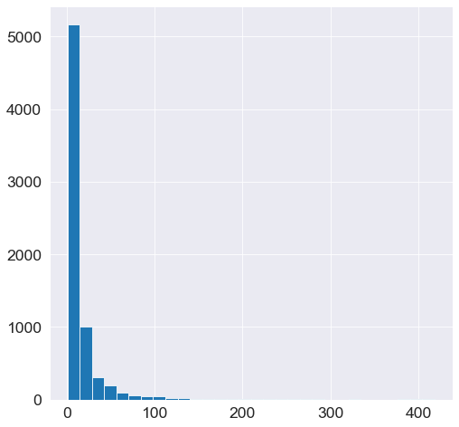

```python
df_cleaned['text_words'].hist(figsize=(8,8),bins=30);
```

### Check for the number of negative text words (blob)

> > Of course few words are easier for bots to create

```python
df_negative_blob['text_words'].value_counts().head(10)
```

```
5     54
8     52
7     48
6     43
4     42
11    41
9     36
19    34
3     33
18    33
Name: text_words, dtype: int64
```

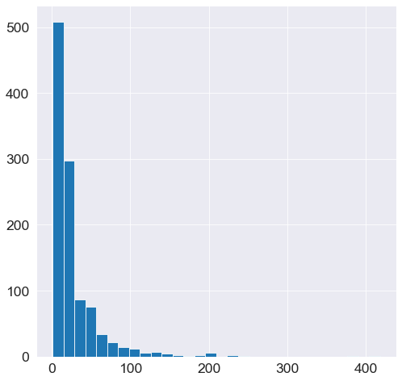

```python
df_negative_blob['text_words'].hist(figsize=(8,8),bins=30);
```

### Most commented user

```python
df_cleaned.author.value_counts()
```

```
-banned-            1666
Night_Chicken        135
AutoModerator         50
emilyguy              38
AutoNewsAdmin         35
                    ...
paracog                1
peter-lovebb           1
danielismyname11       1
Ano_Akamai             1
SmallManBigMouth       1
Name: author, Length: 2963, dtype: int64
```

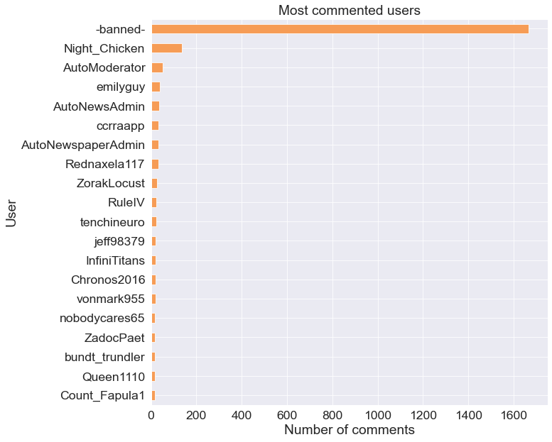

```python
df_cleaned.author.value_counts().head(20).plot(kind='barh', figsize=(10,10), color='#f69c56',
                                                       xlabel = 'User')

plt.gca().invert_yaxis()
plt.xlabel('Number of comments')
plt.title('Most commented users');
```

### Invesigating authors with the most negative comments / submissions (blob)

```python
df_negative_blob.author.value_counts()
```

```
-banned-              164
tenchineuro            15
ZorakLocust            10
j3utton                 9
nobodycares65           9
                     ...
BatTechCrazy            1
fuckgrammarabd          1
ThreeDogPile            1
troyantipastomisto      1
Tek_Freek               1
Name: author, Length: 719, dtype: int64
```

```python
df_negative_blob.author.value_counts().nlargest(n=25)
```

```
-banned-                164
tenchineuro              15
ZorakLocust              10
j3utton                   9
nobodycares65             9
AutoModerator             7
Rogdozz                   7
motadon987                6
No_Revenue                6
DariJC                    5
scyth3s                   5
serjon_arryn              4
jeff98379                 4
Count_Fapula1             4
LovecraftLovejoy          4
bundt_trundler            4
WiseMonkeyGoodMonkey      4
BatmanNewsChris           4
nomnomnomhangry           4
TotesMessenger            4
Rednaxela117              4
mtechnik23                4
djord17                   3
nickvtorres               3
iDevice_Help              3
Name: author, dtype: int64
```

**NOTE:** Some weird names like: nomnomnomhangry

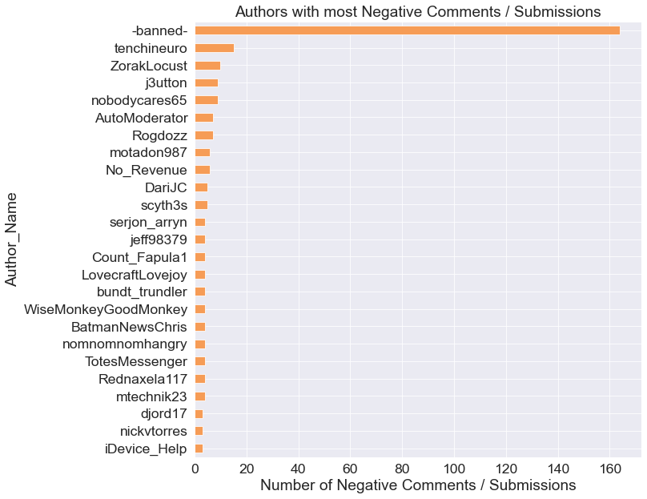

```python
df_negative_blob.author.value_counts().nlargest(n=25).plot(kind='barh', figsize=(10,10), color='#f69c56',
                                                       xlabel = 'Author_Name')

plt.gca().invert_yaxis()
plt.xlabel('Number of Negative Comments / Submissions')
plt.title('Authors with most Negative Comments / Submissions');
```

a lot of negative-comments authors have been banned from Reddit which is great!

### Invesigating authors with the most negative submissions (blob)

```python
df_negative_submission = df_negative_blob[df_negative_blob.submission_comment == 'submission']
print(df_negative_submission.shape)
df_negative_submission.head(2)
```

```
(94, 14)
```

|  | name | permalink | text | parent_id | subreddit | author | created_at | entities.urls | sentiment_blob | sentiment_nltk | top_level | submission_comment | text_words | submission_text |
| --- | --- | --- | --- | --- | --- | --- | --- | --- | --- | --- | --- | --- | --- | --- |
| 37 | t3_7roj2h | /r/JerkOffToCelebs/comments/7roj2h/amber_heardtight_and_wet/ | Amber Heard...tight and wet | NaN | r/JerkOffToCelebs | -banned- | 2018-01-20 05:34:07 | [] | Negative | Neutral | None | submission | 4 | amber_heardtight_and_wet |
| 40 | t3_7rq9ap | /r/dirtypenpals/comments/7rq9ap/22f4a_anyone_with_a_fucked_up_mind_have_a_crush/ | 22f4a - Anyone with a fucked up mind have a crush on Amber Heard, Lexi Belle, Lauren Cohan, Shay Mitchell? | NaN | r/dirtypenpals | -banned- | 2018-01-20 13:02:08 | [] | Negative | Negative | None | submission | 20 | 22f4a_anyone_with_a_fucked_up_mind_have_a_crush |

```python
df_negative_submission.author.value_counts().nlargest(n=10)
```

```
-banned-              35
jeff98379              4
iDevice_Help           3
Tribart3000            3
HugoValentine          2
mscott05101997         2
AutoNewsAdmin          2
AutoNewspaperAdmin     2
Maud_Ford              1
KarmaAccumulator       1
Name: author, dtype: int64
```

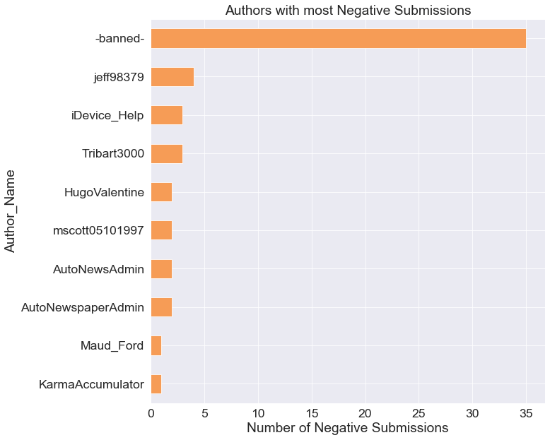

```python
df_negative_submission.author.value_counts().nlargest(n=10).plot(kind='barh', figsize=(10,10), color='#f69c56',
                                                       xlabel = 'Author_Name')

plt.gca().invert_yaxis()
plt.xlabel('Number of Negative Submissions')
plt.title('Authors with most Negative Submissions');
```

### Check wether the users contributing the most to negative comments/submissions are mod, gold or having a verified email

```python
df_negative_blob.author.value_counts().nlargest(n=25)
```

```
-banned-                164
tenchineuro              15
ZorakLocust              10
j3utton                   9
nobodycares65             9
AutoModerator             7
Rogdozz                   7
motadon987                6
No_Revenue                6
DariJC                    5
scyth3s                   5
serjon_arryn              4
jeff98379                 4
Count_Fapula1             4
LovecraftLovejoy          4
bundt_trundler            4
WiseMonkeyGoodMonkey      4
BatmanNewsChris           4
nomnomnomhangry           4
TotesMessenger            4
Rednaxela117              4
mtechnik23                4
djord17                   3
nickvtorres               3
iDevice_Help              3
Name: author, dtype: int64
```

```python
check_list = df_negative_blob.author.value_counts().nlargest(n=25).index.tolist()[1:]
check_list
```

```
['tenchineuro',
 'ZorakLocust',
 'j3utton',
 'nobodycares65',
 'AutoModerator',
 'Rogdozz',
 'motadon987',
 'No_Revenue',
 'DariJC',
 'scyth3s',
 'serjon_arryn',
 'jeff98379',
 'Count_Fapula1',
 'LovecraftLovejoy',
 'bundt_trundler',
 'WiseMonkeyGoodMonkey',
 'BatmanNewsChris',
 'nomnomnomhangry',
 'TotesMessenger',
 'Rednaxela117',
 'mtechnik23',
 'djord17',
 'nickvtorres',
 'iDevice_Help']
```

```python
# get a data frame with the most negative-comments users
df_check = df_users_cleaned[df_users_cleaned['author.name'].isin(check_list)]
print(df_check.shape)
df_check.head(2)
```

```
(22, 5)
```

|  | author.name | author.created_at | author.has_verified_email | author.is_mod | author.is_gold |
| --- | --- | --- | --- | --- | --- |
| 11 | TotesMessenger | 2018-02-04 22:47:06 | True | False | False |
| 7037 | tenchineuro | 2019-10-22 23:03:27 | True | False | False |

```python
df_check['author.name'].nunique()
```

```
22
```

```python
df_check['author.has_verified_email'].value_counts()
```

```
True     19
False     3
Name: author.has_verified_email, dtype: int64
```

```python
df_check['author.is_mod'].value_counts()
```

```
True     12
False    10
Name: author.is_mod, dtype: int64
```

```python
df_check['author.is_gold'].value_counts()
```

```
False    22
Name: author.is_gold, dtype: int64
```

### Most used Subreddits

```python
# def subreddit(permalink):
#     '''
#     get subreddit from permalink
#     '''
#     return re.findall(r'/r/(.*?)/.*?/',permalink)[0]
```

```python
# df_cleaned['permalink'].apply(subreddit).nunique()
```

```python
# df_cleaned['subreddit'] = df_cleaned['permalink'].apply(subreddit)
```

```python
df_cleaned['subreddit'].nunique()
```

```
302
```

```python
df_cleaned['subreddit'] = df_cleaned['subreddit'].str[2:]
```

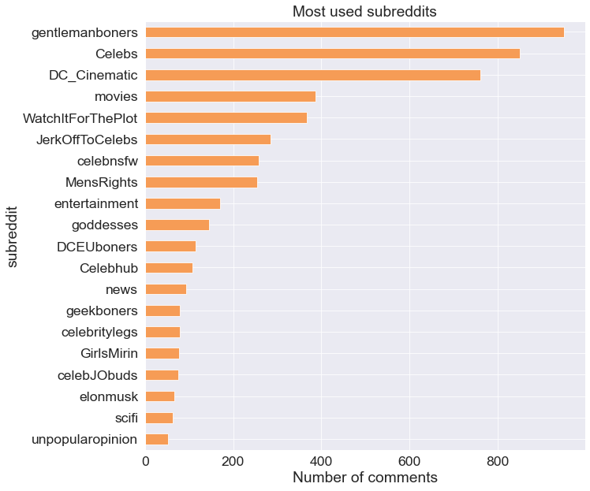

```python
df_cleaned.subreddit.value_counts().head(20).plot(kind='barh', figsize=(10,10), color='#f69c56',
                                                       xlabel = 'subreddit')
plt.gca().invert_yaxis()
plt.xlabel('Number of comments')
plt.title('Most used subreddits');
```

### Invesigating subreddits with the most negative comments (blob)

```python
df_negative_blob.subreddit.value_counts()
```

```
r/DC_Cinematic        127
r/gentlemanboners     126
r/MensRights           98
r/movies               95
r/Celebs               67
                     ...
r/NewsOfTheStupid       1
r/CelebrityPokies       1
r/CelebrityCandids      1
r/CelebSexScenes        1
r/Amber                 1
Name: subreddit, Length: 107, dtype: int64
```

```python
df_negative_blob.subreddit.value_counts().nlargest(n=25)
```

```
r/DC_Cinematic          127
r/gentlemanboners       126
r/MensRights             98
r/movies                 95
r/Celebs                 67
r/WatchItForThePlot      60
r/entertainment          58
r/JerkOffToCelebs        57
r/celebnsfw              38
r/news                   22
r/scifi                  18
r/GirlsMirin             16
r/celebJObuds            15
r/Drama                  15
r/elonmusk               14
r/unpopularopinion       12
r/crappycontouring       12
r/funkopop               11
r/Celebhub               10
r/EnoughMuskSpam         10
r/CelebAssPussyMouth     10
r/goddesses              10
r/GamerGhazi              9
r/geekboners              9
r/celebrities             7
Name: subreddit, dtype: int64
```

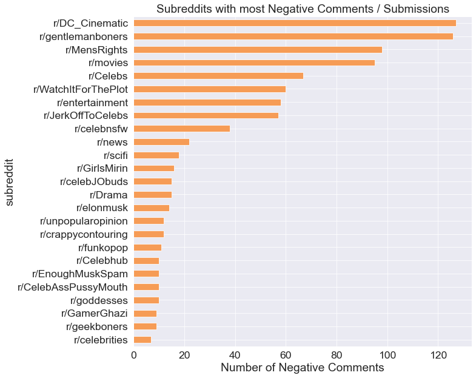

```python
df_negative_blob.subreddit.value_counts().nlargest(n=25).plot(kind='barh', figsize=(10,10), color='#f69c56',
                                                       xlabel = 'subreddit')

plt.gca().invert_yaxis()
plt.xlabel('Number of Negative Comments')
plt.title('Subreddits with most Negative Comments / Submissions');
```

Subreddits with the most negative comments are almost the same as the most used subreddits

### Submission URLS

```python
# Filter the dataframe on entity urls that has values
# df_cleaned[df_cleaned['entities.urls'].notnull()] --> work only with NaN not empty lists
df_cleaned[df_cleaned['entities.urls'].map(len) > 0] # --> didn't work for me
df_cleaned[df_cleaned.astype(str)['entities.urls'] != '[]'].head(2)
```

|  | name | permalink | text | parent_id | subreddit | author | created_at | entities.urls | sentiment_blob | sentiment_nltk | top_level | submission_comment | text_words | submission_text |
| --- | --- | --- | --- | --- | --- | --- | --- | --- | --- | --- | --- | --- | --- | --- |
| 25 | t1_dt63kag | /r/goddesses/comments/7sgl66/amber_heard/dt63kag/ | [Imogen Poots](https://en.wikipedia.org/wiki/Imogen_Poots) | t1_dt5pz1p | goddesses | Estoye | 2018-01-24 15:27:05 | [{'display_url': 'https://en.wikipedia.org'}] | Neutral | Neutral | comment | comment | 2 | amber_heard |
| 58 | t1_dsqjci3 | /r/Celebs/comments/7qnuyt/amber_heard/dsqjci3/ | This submission has been automatically removed due to linking to an unapproved domain. Please re-upload the image to a quality image host such as [imgur](http://imgur.com) or [gfycat](http://gfycat.co… | t3_7qnuyt | Celebs | AutoModerator | 2018-01-15 23:11:18 | [{'display_url': 'http://imgur.com'}, {'display_url': 'http://gfycat.com'}] | Negative | Positive | submission | comment | 53 | amber_heard |

```python
df_cleaned['entities.urls'].value_counts().head(5)
```

```
[]                                              6761
[{'display_url': 'https://t.co'}]                 22
[{'display_url': 'https://www.reddit.com'}]       21
[{'display_url': 'https://youtu.be'}]             10
[{'display_url': 'https://www.youtube.com'}]       9
Name: entities.urls, dtype: int64
```

```python
df_cleaned['entities.urls'].nunique()
```

```
113
```

```python
df_cleaned['entities.urls'].unique()
```

```
array(['[]', "[{'display_url': 'https://en.wikipedia.org'}]",
       "[{'display_url': 'http://imgur.com'}, {'display_url': 'http://gfycat.com'}]",
       "[{'display_url': 'https://youtu.be'}]",
       "[{'display_url': 'https://t.co'}]",
       "[{'display_url': 'http://redd.it'}, {'display_url': 'https://www.reddit.com'}]",
       "[{'display_url': 'http://docs.cpuc.ca.gov'}]",
       "[{'display_url': 'https://np.reddit.com'}, {'display_url': 'https://i.imgur.com'}, {'display_url': 'https://np.reddit.com'}, {'display_url': 'https://i.redd.it'}, {'display_url': 'https://np.reddit.com'}, {'display_url': 'https://np.reddit.com'}, {'display_url': 'https://www.reddit.com'}, {'…
       "[{'display_url': 'https://www.instagram.com'}, {'display_url': 'https://www.Twitter.com'}, {'display_url': 'https://www.youtube.com'}, {'display_url': 'https://www.Facebook.com'}, {'display_url': 'https://www.IMDB.com'}, {'display_url': 'https://www.google.com'}, {'display_url': 'https://www…
       "[{'display_url': 'https://www.maxim.com'}]",
       "[{'display_url': 'https://www.reddit.com'}]",
       "[{'display_url': 'https://thumbs.gfycat.com'}]",
       "[{'display_url': 'http://www.tmz.com'}]",
       "[{'display_url': 'https://en.m.wikipedia.org'}]",
       "[{'display_url': 'https://gfycat.com'}]",
       "[{'display_url': 'http://redd.it'}, {'display_url': 'http://redd.it'}, {'display_url': 'http://redd.it'}, {'display_url': 'http://redd.it'}, {'display_url': 'http://redd.it'}, {'display_url': 'http://redd.it'}, {'display_url': 'http://redd.it'}, {'display_url': 'http://redd.it'}, {'display_u…
       "[{'display_url': 'http://i0.kym-cdn.com'}]",
       "[{'display_url': 'https://i.imgur.com'}]",
       "[{'display_url': 'https://www.reddit.com'}, {'display_url': 'https://reddit.com'}]",
       "[{'display_url': 'https://www.rollingstone.com'}]",
       "[{'display_url': 'https://www.marieclaire.com'}]",
       "[{'display_url': 'http://cache.boston.com'}]",
       "[{'display_url': 'https://www.reddit.com'}, {'display_url': 'https://www.reddit.com'}]",
       "[{'display_url': 'http://www.imdb.com'}]",
       "[{'display_url': 'https://m.youtube.com'}]",
       "[{'display_url': 'https://www.reddit.com'}, {'display_url': 'http://www.reddit.com'}, {'display_url': 'http://www.reddit.com'}]",
       "[{'display_url': 'https://discordapp.com'}]",
       "[{'display_url': 'https://media.giphy.com'}]",
       "[{'display_url': 'https://twitter.com'}]",
       "[{'display_url': 'https://www.apatico.net'}]",
       "[{'display_url': 'https://np.reddit.com'}, {'display_url': 'https://np.reddit.com'}]",
       "[{'display_url': 'https://www.youtube.com'}]",
       "[{'display_url': 'https://imgur.com'}]",
       "[{'display_url': 'https://www.reddit.com'}, {'display_url': 'https://www.reddit.com'}, {'display_url': 'https://www.reddit.com'}]",
       "[{'display_url': 'https://www'}, {'display_url': 'https://www.reddit.com'}]",
       "[{'display_url': 'https://cdn1.thr.com'}]",
       "[{'display_url': 'http://www.votetexas.gov'}, {'display_url': 'https://teamrv-mvp.sos.texas.gov'}, {'display_url': 'https://teamrv-mvp.sos.texas.gov'}]",
       "[{'display_url': 'https://twitter.com'}, {'display_url': 'https://www.buzzfeed.com'}, {'display_url': 'https://www.buzzfeed.com'}]",
       "[{'display_url': 'https://unv.is'}, {'display_url': 'http://www.dailymail.co.uk'}, {'display_url': 'http://i.dailymail.co.uk'}, {'display_url': 'http://i.dailymail.co.uk'}, {'display_url': 'http://i.dailymail.co.uk'}, {'display_url': 'http://i.dailymail.co.uk'}, {'display_url': 'http://i.dai…
       "[{'display_url': 'https://i.imgur.com'}, {'display_url': 'https://www.reddit.com'}, {'display_url': 'https://github.com'}]",
       "[{'display_url': 'http://i.imgur.com'}, {'display_url': 'https://www.youtube.com'}, {'display_url': 'https://youtu.be'}]",
```

[output cut: 57 more lines]

```
       "[{'display_url': 'https://web.archive.org'}, {'display_url': 'http://www.reddit.com'}, {'display_url': 'https://megalodon.jp'}, {'display_url': 'https://www.removeddit.com'}, {'display_url': 'https://archive.is'}, {'display_url': 'https://np.reddit.com'}, {'display_url': 'https://web.archive…
       "[{'display_url': 'https://www.theloop.ca'}]",
       "[{'display_url': 'https://web.archive.org'}, {'display_url': 'http://www.reddit.com'}, {'display_url': 'https://megalodon.jp'}, {'display_url': 'https://www.removeddit.com'}, {'display_url': 'https://archive.is'}]",
       "[{'display_url': 'https://eu.usatoday.com'}]",
       "[{'display_url': 'https://www.theguardian.com'}]",
       "[{'display_url': 'http://www.wolframalpha.com'}, {'display_url': 'https://www.reddit.com'}, {'display_url': 'http://np.reddit.com'}, {'display_url': 'https://www.reddit.com'}, {'display_url': 'http://np.reddit.com'}, {'display_url': 'http://np.reddit.com'}, {'display_url': 'http://np.reddit.…
       "[{'display_url': 'https://www.foxnews.com'}]",
       "[{'display_url': 'https://www.imdb.com'}]",
       "[{'display_url': 'https://www.instagram.com'}]",
       "[{'display_url': 'https://akns-images.eonline.com'}]",
       "[{'display_url': 'https://i.imgur.com'}, {'display_url': 'https://i.imgur.com'}, {'display_url': 'https://i.imgur.com'}, {'display_url': 'https://i.imgur.com'}]",
       "[{'display_url': 'https://66.media.tumblr.com'}, {'display_url': 'https://66.media.tumblr.com'}, {'display_url': 'https://github.com'}, {'display_url': 'http://www.reddit.com'}]",
       "[{'display_url': 'https://www.writeups.org'}, {'display_url': 'http://3.bp.blogspot.com'}]",
       "[{'display_url': 'https://www.thenipslip.com'}]",
       "[{'display_url': 'https://ew.com'}]"], dtype=object)
```

```python
# REGEX | : '(.*?)'}
# () --> capyure and group
# . --> any character except \n
# * --> zero or more occurences
# ? --> means that the previous character is optional (either one or zero of it is allowed)

def get_urls(entity):
    result = re.findall(r": '(.*?)'}", entity)
    if len(result) == -1:
        return np.nan
    else:
        return result
```

```python
df_cleaned['urls'] = df_cleaned['entities.urls'].apply(get_urls)
```

```python
helpers.object_dtype(df_cleaned)
```

```
name <class 'str'>
permalink <class 'str'>
text <class 'str'>
parent_id <class 'float'>
subreddit <class 'str'>
author <class 'str'>
entities.urls <class 'str'>
sentiment_blob <class 'str'>
sentiment_nltk <class 'str'>
top_level <class 'NoneType'>
submission_comment <class 'str'>
submission_text <class 'str'>
urls <class 'list'>
```

```python
df_cleaned['urls_count'] = df_cleaned['urls'].apply(len)
```

```python
df_cleaned[df_cleaned.astype(str)['entities.urls'] != '[]'].head(2)
```

|  | name | permalink | text | parent_id | subreddit | author | created_at | entities.urls | sentiment_blob | sentiment_nltk | top_level | submission_comment | text_words | submission_text | urls | urls_count |
| --- | --- | --- | --- | --- | --- | --- | --- | --- | --- | --- | --- | --- | --- | --- | --- | --- |
| 25 | t1_dt63kag | /r/goddesses/comments/7sgl66/amber_heard/dt63kag/ | [Imogen Poots](https://en.wikipedia.org/wiki/Imogen_Poots) | t1_dt5pz1p | goddesses | Estoye | 2018-01-24 15:27:05 | [{'display_url': 'https://en.wikipedia.org'}] | Neutral | Neutral | comment | comment | 2 | amber_heard | [https://en.wikipedia.org] | 1 |
| 58 | t1_dsqjci3 | /r/Celebs/comments/7qnuyt/amber_heard/dsqjci3/ | This submission has been automatically removed due to linking to an unapproved domain. Please re-upload the image to a quality image host such as [imgur](http://imgur.com) or [gfycat](http://gfycat.co… | t3_7qnuyt | Celebs | AutoModerator | 2018-01-15 23:11:18 | [{'display_url': 'http://imgur.com'}, {'display_url': 'http://gfycat.com'}] | Negative | Positive | submission | comment | 53 | amber_heard | [http://imgur.com, http://gfycat.com] | 2 |

```python
df_cleaned['urls'].astype('str').value_counts()
```

```
[]                                                                                                                                                                                                                                                  6761
['https://t.co']                                                                                                                                                                                                                                      22
['https://www.reddit.com']                                                                                                                                                                                                                            21
['https://youtu.be']                                                                                                                                                                                                                                  10
['https://www.instagram.com', 'https://www.Twitter.com', 'https://www.youtube.com', 'https://www.Facebook.com', 'https://www.IMDB.com', 'https://www.google.com', 'https://www.youtube.com', 'https://www.reddit.com', 'https://www.reddit.com']       9
                                                                                                                                                                                                                                                    ...
['https://www.instagram.com']                                                                                                                                                                                                                          1
['http://www.indiewire.com']                                                                                                                                                                                                                           1
['https://pagesix.com']                                                                                                                                                                                                                                1
['https://cdn1.thr.com']                                                                                                                                                                                                                               1
['http://imgur.com']                                                                                                                                                                                                                                   1
Name: urls, Length: 113, dtype: int64
```

```python
# the value counts of urls count
df_cleaned['urls_count'].value_counts()
```

```
0     6761
1      160
2       24
3       16
9       10
5        7
4        5
6        2
7        2
8        1
12       1
21       1
41       1
10       1
11       1
Name: urls_count, dtype: int64
```

```python
# df_cleaned['urls'].value_counts()[1:] --> this is all values except for empty lists
# (df_cleaned.shape[0] - df_cleaned['urls'].value_counts()[0]) --> non empty lists count

# df_cleaned['urls'].value_counts()[1:] / (df_cleaned.shape[0] - df_cleaned['urls'].value_counts()[0])
```

### Invesigating the sumbissions with most comments

```python
df_cleaned.parent_id.value_counts()
```

```
t3_91hqrc     49
t3_a6i1j4     40
t3_a7lypo     36
t3_9uzs60     34
t3_8hx1bz     30
              ..
t1_dubrku9     1
t1_ecmoclu     1
t1_ebbhhux     1
t1_e0qg7wl     1
t1_e8yp66p     1
Name: parent_id, Length: 2695, dtype: int64
```

t3 --> sumbission  
t3_91hqrc (49) --> means 49 comment on the same submission

We can convert value_counts to_dataframe and filter on the submissions only (t3)

```python
df_cleaned.parent_id.value_counts().nlargest(n=25)
```

```
t3_91hqrc    49
t3_a6i1j4    40
t3_a7lypo    36
t3_9uzs60    34
t3_8hx1bz    30
t3_a4n9u2    29
t3_7vr5ia    29
t3_8uiuca    26
t3_96g1on    24
t3_962owo    24
t3_8ozhus    23
t3_9smlbt    21
t3_93iyoe    21
t3_97ptaf    20
t3_910nqx    20
t3_843pf0    20
t3_9v15hd    18
t3_8vjzd0    18
t3_99ck9j    17
t3_8694b7    16
t3_8l6x7k    16
t3_8c7imd    15
t3_a8ltwz    14
t3_ab2eg4    13
t3_8c2e0d    13
Name: parent_id, dtype: int64
```

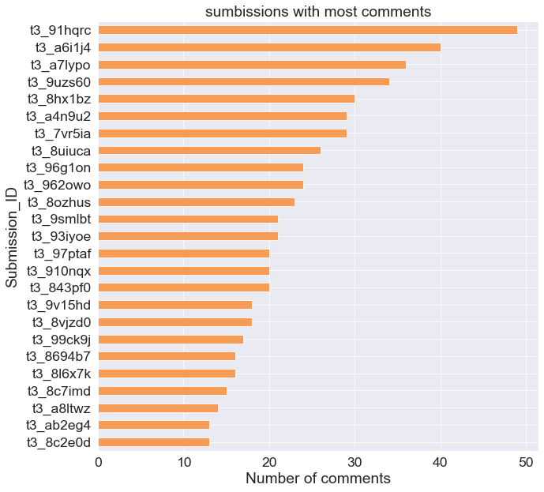

```python
df_cleaned.parent_id.value_counts().nlargest(n=25).plot(kind='barh', figsize=(10,10), color='#f69c56',
                                                       xlabel = 'Submission_ID')

plt.gca().invert_yaxis()
plt.xlabel('Number of comments')
plt.title('sumbissions with most comments');
```

### Invesigating submissions with the most negative comments (blob)

```python
# first get a DataFrame of the negative comments only
# df_negative_blob = df_cleaned.query("sentiment_blob == 'Negative'") --> defined above
```

```python
df_negative_blob.parent_id.value_counts()
```

```
t3_a7lypo     13
t3_8hx1bz     11
t3_910nqx      8
t3_97ptaf      8
t3_7vr5ia      8
              ..
t1_e4nqkdv     1
t1_ec4g3us     1
t1_ec4puwk     1
t1_e4a8ad9     1
t1_dtuxdmy     1
Name: parent_id, Length: 745, dtype: int64
```

```python
df_negative_blob.parent_id.value_counts().nlargest(n=25)
```

```
t3_a7lypo     13
t3_8hx1bz     11
t3_910nqx      8
t3_97ptaf      8
t3_7vr5ia      8
t3_93iyoe      7
t3_a6i1j4      7
t3_8uiuca      6
t3_a7mewx      6
t3_962owo      6
t3_9smlbt      5
t3_96g1on      5
t3_9uzs60      5
t3_99ck9j      4
t3_8gdrmz      4
t3_91h1om      4
t3_998n9e      4
t3_a7ygvb      4
t3_843pf0      4
t3_8oysp0      4
t3_a7tbq0      4
t3_8vszy7      4
t3_97sq5b      4
t1_ec48nuy     3
t3_82z9f0      3
Name: parent_id, dtype: int64
```

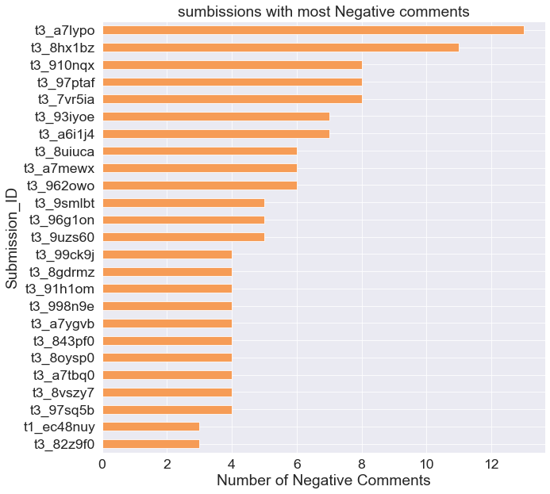

```python
df_negative_blob.parent_id.value_counts().nlargest(n=25).plot(kind='barh', figsize=(10,10), color='#f69c56',
                                                       xlabel = 'Submission_ID')

plt.gca().invert_yaxis()
plt.xlabel('Number of Negative Comments')
plt.title('sumbissions with most Negative comments');
```

- Daily Creation Data
- User Charcterstics
- Reddit Comments/Submissions Data
- **Merged Users Data with Comments/Submissions Data**

### Merging Users Data with Comments & Submissions Data

```python
reddit_df = pd.merge(df_cleaned, df_users_cleaned, left_on = 'author',right_on = 'author.name') # , how='left'
print(reddit_df.shape)
reddit_df.head(1)
```

```
(3918, 21)
```

|  | name | permalink | text | parent_id | subreddit | author | created_at | entities.urls | sentiment_blob | sentiment_nltk | ... | submission_comment | text_words | submission_text | urls | urls_count | author.name | author.created_at | author.has_verified_email | author.is_mod | author.is_gold |
| --- | --- | --- | --- | --- | --- | --- | --- | --- | --- | --- | --- | --- | --- | --- | --- | --- | --- | --- | --- | --- | --- |
| 0 | t3_7u8w98 | /r/CelebrityArmpits/comments/7u8w98/amber_heard_aic/ | Amber Heard [AIC] | NaN | CelebrityArmpits | pitsnbush | 2018-01-31 10:05:02 | [] | Neutral | Neutral | ... | submission | 3 | amber_heard_aic | [] | 0 | pitsnbush | 2013-03-27 08:05:46 | True | True | False |

1 rows × 21 columns

```python
# drop the columns we are not gonna use further
drop_list = ['permalink', 'entities.urls', 'urls', 'urls_count', 'text_words', 'author']
reddit_df.drop(columns=drop_list, inplace=True)
```

### Difference in time between creating the account and posting

```python
reddit_df['diff'] = abs(reddit_df['author.created_at'] - reddit_df['created_at'])
reddit_df.head(1)
```

|  | name | text | parent_id | subreddit | created_at | sentiment_blob | sentiment_nltk | top_level | submission_comment | submission_text | author.name | author.created_at | author.has_verified_email | author.is_mod | author.is_gold | diff |
| --- | --- | --- | --- | --- | --- | --- | --- | --- | --- | --- | --- | --- | --- | --- | --- | --- |
| 0 | t3_7u8w98 | Amber Heard [AIC] | NaN | CelebrityArmpits | 2018-01-31 10:05:02 | Neutral | Neutral | None | submission | amber_heard_aic | pitsnbush | 2013-03-27 08:05:46 | True | True | False | 1771 days 01:59:16 |

```python
reddit_df.info()
```

```
<class 'pandas.core.frame.DataFrame'>
Int64Index: 3918 entries, 0 to 3917
Data columns (total 16 columns):
 #   Column                     Non-Null Count  Dtype
---  ------                     --------------  -----
 0   name                       3918 non-null   object
 1   text                       3918 non-null   object
 2   parent_id                  2993 non-null   object
 3   subreddit                  3918 non-null   object
 4   created_at                 3918 non-null   datetime64[ns]
 5   sentiment_blob             3918 non-null   object
 6   sentiment_nltk             3918 non-null   object
 7   top_level                  2993 non-null   object
 8   submission_comment         3918 non-null   object
 9   submission_text            3918 non-null   object
 10  author.name                3918 non-null   object
 11  author.created_at          3918 non-null   datetime64[ns]
 12  author.has_verified_email  3913 non-null   object
 13  author.is_mod              3918 non-null   bool
 14  author.is_gold             3918 non-null   bool
 15  diff                       3918 non-null   timedelta64[ns]
dtypes: bool(2), datetime64[ns](2), object(11), timedelta64[ns](1)
memory usage: 466.8+ KB
```

```python
reddit_df["days_after_account_creation"] = reddit_df["diff"].astype(str).str.split(" ").str[0]
reddit_df["days_after_account_creation"] = reddit_df["days_after_account_creation"].astype('int')
reddit_df["days_after_account_creation"].dtype
```

```
dtype('int64')
```

```python
# note that value_counts() neglect Zeros
reddit_df["days_after_account_creation"].value_counts()
```

```
27      137
920      84
291      53
446      44
347      40
       ...
2819      1
2438      1
774       1
784       1
2021      1
Name: days_after_account_creation, Length: 1171, dtype: int64
```

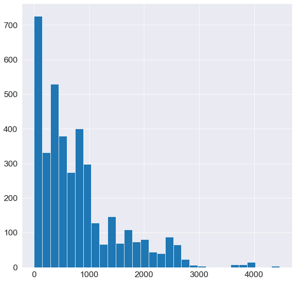

```python
reddit_df["days_after_account_creation"].hist(figsize = (10, 10) , bins = 30);
```

### Posting Duration After Account Creation

```python
reddit_df[reddit_df['days_after_account_creation'] == 0].shape[0]
```

```
13
```

13 accounts posted the same day they was created!

```python
reddit_df[reddit_df['days_after_account_creation'] <= 7].shape[0]
```

```
70
```

70 accounts posted the same week they was created!

```python
reddit_df[reddit_df['days_after_account_creation'] <= 30].shape[0]
```

```
332
```

332 accounts posted the same month they was created!

```python
reddit_df[reddit_df['days_after_account_creation'] <= 30]['author.created_at'].dt.year.value_counts()
```

```
2018    331
2019      1
Name: author.created_at, dtype: int64
```

we can find that the author_created_year is 2018 --> the year the movement started to influence the social media

```python
reddit_df[reddit_df['days_after_account_creation'] <= 30]['author.created_at'].dt.strftime('%b').value_counts()
```

```
Sep    134
Jul     59
Dec     50
Jun     28
Nov     18
Oct     12
May      9
Aug      8
Feb      8
Apr      4
Jan      2
Name: author.created_at, dtype: int64
```

```python
reddit_df.drop(columns = 'days_after_account_creation', inplace=True)
```

### Estimation of Number of User Accounts Created / having negative contributions (blob)

```python
reddit_negative = reddit_df[reddit_df['sentiment_blob'] == 'Negative']
print(reddit_negative.shape)
reddit_negative.head(2)
```

```
(686, 16)
```

|  | name | text | parent_id | subreddit | created_at | sentiment_blob | sentiment_nltk | top_level | submission_comment | submission_text | author.name | author.created_at | author.has_verified_email | author.is_mod | author.is_gold | diff |
| --- | --- | --- | --- | --- | --- | --- | --- | --- | --- | --- | --- | --- | --- | --- | --- | --- |
| 36 | t1_dsygyxg | She would be a really fun fuck... | t3_7roj2h | JerkOffToCelebs | 2018-01-20 05:38:22 | Negative | Positive | submission | comment | amber_heardtight_and_wet | DariJC | 2017-06-30 23:33:18 | True | True | False | 203 days 06:05:04 |
| 38 | t1_e4xbxip | Giving her a rough fuck would be incredibly fun. Doggystyle, smacking her ass making her moan and scream. Seeing her lay on her stomach, breathing hard recovering afterwards, her blonde hair messily c… | t3_9aqp5j | JerkOffToCelebs | 2018-08-27 17:03:46 | Negative | Neutral | submission | comment | amber_heard | DariJC | 2017-06-30 23:33:18 | True | True | False | 422 days 17:30:28 |

```python
# the negative contributions of user accounts created in each year
negative_contributions = reddit_negative.groupby(reddit_negative['author.created_at'].dt.year).size().reset_index(name='year_count')
negative_contributions
```

|  | author.created_at | year_count |
| --- | --- | --- |
| 0 | 2006 | 1 |
| 1 | 2008 | 7 |
| 2 | 2009 | 2 |
| 3 | 2011 | 18 |
| 4 | 2012 | 10 |
| 5 | 2013 | 42 |
| 6 | 2014 | 44 |
| 7 | 2015 | 60 |
| 8 | 2016 | 166 |
| 9 | 2017 | 144 |
| 10 | 2018 | 114 |
| 11 | 2019 | 42 |
| 12 | 2020 | 26 |
| 13 | 2021 | 10 |

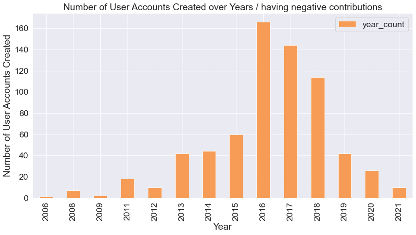

```python
negative_contributions.plot(x="author.created_at", y="year_count", kind="bar", figsize=(14,7), color='#f69c56')
plt.xlabel('Year')
plt.ylabel('Number of User Accounts Created')
plt.title('Number of User Accounts Created over Years / having negative contributions');
```

### Which dates has the highest contrbitions for users?

```python
df_cleaned.created_at.value_counts()
```

```
2018-11-20 08:19:42    2
2018-02-27 13:37:37    2
2018-10-04 16:45:33    2
2018-11-29 21:36:33    2
2018-07-03 17:12:14    2
                      ..
2018-04-14 04:24:03    1
2018-08-01 00:36:29    1
2018-12-06 20:07:47    1
2018-12-03 19:43:07    1
2018-11-07 17:33:46    1
Name: created_at, Length: 6962, dtype: int64
```

```python
df_cleaned.created_at.dt.date.value_counts()
```

```
2018-12-19    244
2018-07-03    190
2018-12-20    150
2018-07-22    137
2018-07-24    128
             ...
2018-01-30      1
2018-02-26      1
2018-06-27      1
2018-03-02      1
2018-01-21      1
Name: created_at, Length: 352, dtype: int64
```

```python
# group by date an count
trendy_dates = df_cleaned.groupby(df_cleaned['created_at'].dt.date).agg('count')['created_at'].to_frame()

# naming the count column as  contribution_count
trendy_dates.columns = ['contribution_count']
trendy_dates.sort_values('contribution_count', ascending=False, inplace=True)

trendy_dates.reset_index()
```

|  | created_at | contribution_count |
| --- | --- | --- |
| 0 | 2018-12-19 | 244 |
| 1 | 2018-07-03 | 190 |
| 2 | 2018-12-20 | 150 |
| 3 | 2018-07-22 | 137 |
| 4 | 2018-07-24 | 128 |
| ... | ... | ... |
| 347 | 2018-02-26 | 1 |
| 348 | 2018-04-04 | 1 |
| 349 | 2018-10-07 | 1 |
| 350 | 2018-02-19 | 1 |
| 351 | 2018-05-04 | 1 |

352 rows × 2 columns

```python
# get the top 15 trendy dates first, then sort them by date
top_trendy_dates = trendy_dates.head(15)
top_trendy_dates.sort_values('created_at', inplace=True)
```

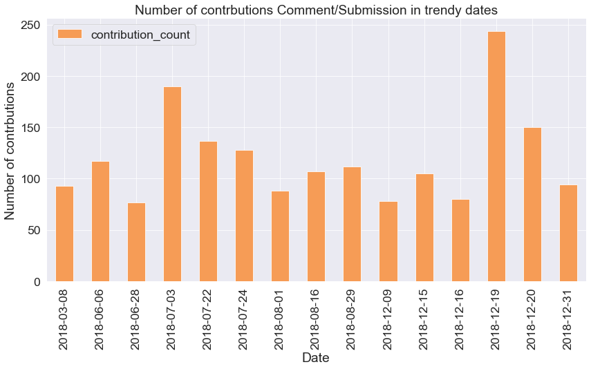

```python
top_trendy_dates.head(15).reset_index().plot(x='created_at', y="contribution_count", kind="bar", figsize=(14,7), color='#f69c56')
plt.xlabel('Date')
plt.ylabel('Number of contrbutions')
plt.title('Number of contrbutions Comment/Submission in trendy dates');
```

https://pandas-docs.github.io/pandas-docs-travis/reference/api/pandas.DataFrame.hist.html

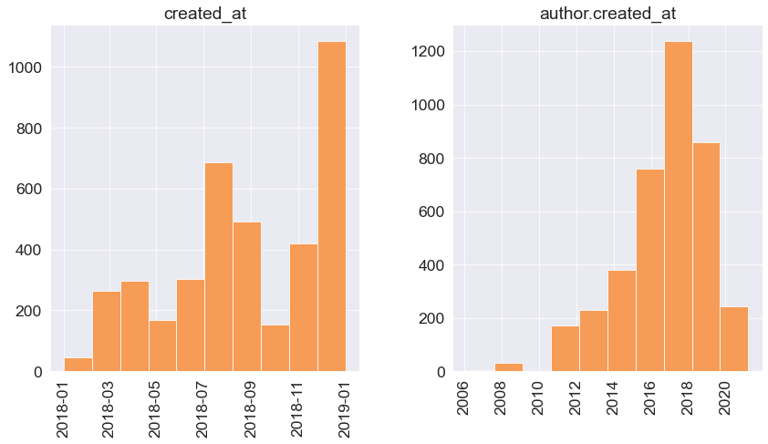

```python
reddit_df.hist(figsize=(14,7), color='#f69c56', xrot = 90);
# plt.xticks(rotation=90);
```

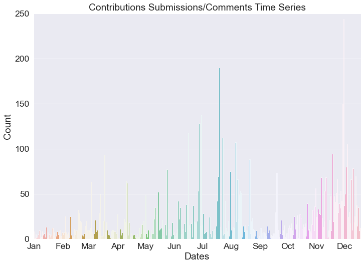

```python
# Contributions Submissions/Comments Time Series For 2018
date = df_cleaned['created_at'].dt.date

fig, ax = plt.subplots()
fig.set_size_inches(11.7, 8.27)
sns.countplot(x = date, data = df_cleaned)
ax.xaxis.set_major_locator(mdates.MonthLocator())
ax.xaxis.set_major_formatter(mdates.DateFormatter('%b'))
#plt.xticks([1,2,3,4,5,6,7,8,9,10,11,12])
plt.xlabel('Dates')
plt.ylim(0,250)
plt.ylabel('Count')
plt.title('Contributions Submissions/Comments Time Series')
plt.show()
```

In Which days users created more?

```python
week_day = df_cleaned['created_at'].dt.strftime('%a')
# one can sort by any order by providing a custom index explicitely :
# https://stackoverflow.com/questions/43855474/changing-sort-in-value-counts/43855492
week_sorted = week_day.value_counts()[['Mon', 'Tue', 'Wed', 'Thu', 'Fri', 'Sat', 'Sun']]
week_sorted
```

```
Mon     811
Tue    1111
Wed    1406
Thu    1185
Fri     865
Sat     741
Sun     874
Name: created_at, dtype: int64
```

https://realpython.com/pandas-sort-python/

https://www.py4u.net/discuss/11286

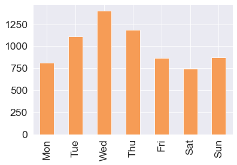

```python
week_sorted.plot(kind='bar', color='#f69c56');
# plt.gca().invert_xaxis()
```

In Which months users created more?

```python
month_day = df_cleaned['created_at'].dt.strftime('%b')
month_sorted = month_day.value_counts()[['Jan', 'Feb', 'Mar', 'Apr', 'May', 'Jun', 'Jul', 'Aug', 'Sep', 'Oct', 'Nov', 'Dec']]
month_sorted
```

```
Jan     146
Feb     239
Mar     466
Apr     332
May     421
Jun     592
Jul     938
Aug     883
Sep     182
Oct     438
Nov     731
Dec    1625
Name: created_at, dtype: int64
```

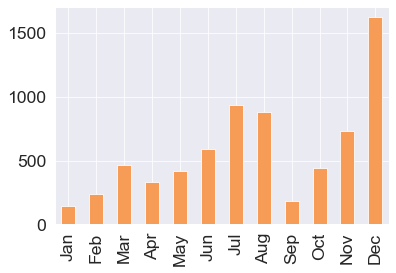

```python
month_sorted.plot(kind='bar', color='#f69c56');
# plt.gca().invert_xaxis()
```

### Which dates has the highest negative contrbitions for users?

```python
# grop by date and count
trendy_dates_negative = df_negative_blob.groupby(df_negative_blob['created_at'].dt.date).agg('count')['created_at'].to_frame()


# naming the count column as contribution_count
trendy_dates_negative.columns = ['contribution_count']
trendy_dates_negative.sort_values('contribution_count', ascending=False, inplace=True)

trendy_dates_negative.head()
trendy_dates_negative.reset_index()
```

|  | created_at | contribution_count |
| --- | --- | --- |
| 0 | 2018-12-19 | 90 |
| 1 | 2018-12-20 | 39 |
| 2 | 2018-07-03 | 35 |
| 3 | 2018-07-22 | 35 |
| 4 | 2018-08-01 | 33 |
| ... | ... | ... |
| 224 | 2018-08-03 | 1 |
| 225 | 2018-03-24 | 1 |
| 226 | 2018-03-25 | 1 |
| 227 | 2018-03-28 | 1 |
| 228 | 2018-07-20 | 1 |

229 rows × 2 columns

```python
# get the top 15 trendy dates first, then sort them by date
top_trendy_negative = trendy_dates_negative.head(15)
top_trendy_negative.sort_values('created_at', inplace=True)
```

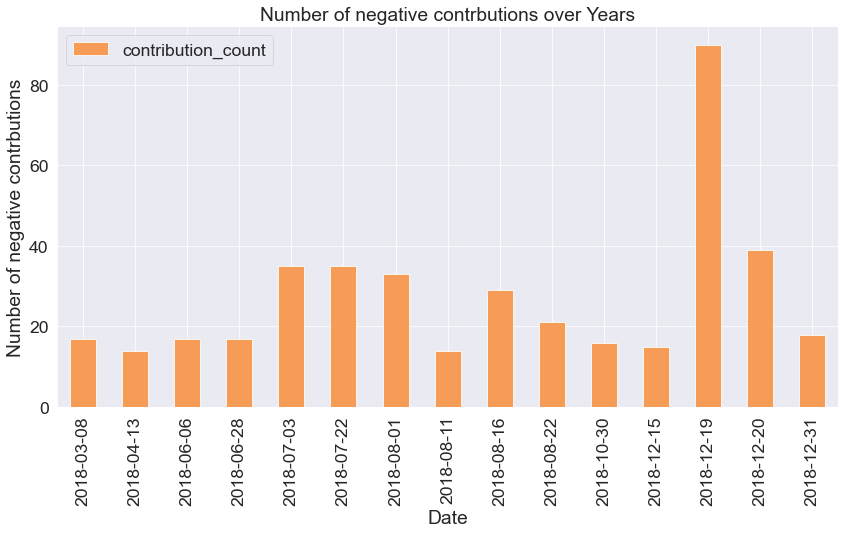

```python
top_trendy_negative.head(15).reset_index().plot(x='created_at', y="contribution_count", kind="bar", figsize=(14,7), color='#f69c56')
plt.xlabel('Date')
plt.ylabel('Number of negative contrbutions')
plt.title('Number of negative contrbutions over Years');
```

**NOTE:** a lot of negative contributions on 19-12-2018!

[figure not shown]

```python
# Negative Contributions Submissions/Comments Time Series For 2018
date = df_negative_blob['created_at'].dt.date

fig, ax = plt.subplots()
fig.set_size_inches(11.7, 8.27)
sns.countplot(x = date, data = df_negative_blob)
ax.xaxis.set_major_locator(mdates.MonthLocator())
ax.xaxis.set_major_formatter(mdates.DateFormatter('%b'))
#plt.xticks([1,2,3,4,5,6,7,8,9,10,11,12])
plt.xlabel('Dates')
plt.ylim(0,100)
plt.ylabel('Count')
plt.title('Negative Contributions Submissions/Comments Time Series')
plt.show()
```

In Which days accounts created more negative comments

```python
week_day_negative = df_negative_blob['created_at'].dt.strftime('%a')
# one can sort by any order by providing a custom index explicitely :
# https://stackoverflow.com/questions/43855474/changing-sort-in-value-counts/43855492
week_day_negative_sorted = week_day_negative.value_counts()[['Mon', 'Tue', 'Wed', 'Thu', 'Fri', 'Sat', 'Sun']]
week_day_negative_sorted
```

```
Mon    108
Tue    163
Wed    276
Thu    195
Fri    103
Sat    110
Sun    128
Name: created_at, dtype: int64
```

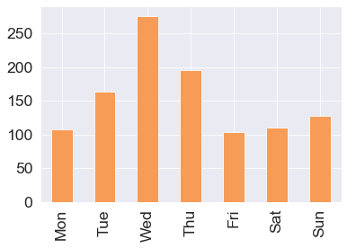

```python
week_day_negative_sorted.plot(kind='bar', color='#f69c56');
# plt.gca().invert_xaxis()
```

In Which months accounts created more negative comments?

```python
month_day_negative = df_negative_blob['created_at'].dt.strftime('%b')
month_day_negative_sorted = month_day_negative.value_counts()[['Jan', 'Feb', 'Mar', 'Apr', 'May', 'Jun', 'Jul', 'Aug', 'Sep', 'Oct', 'Nov', 'Dec']]
month_day_negative_sorted
```

```
Jan     25
Feb     40
Mar     65
Apr     49
May     70
Jun     84
Jul    149
Aug    166
Sep     18
Oct     46
Nov     88
Dec    283
Name: created_at, dtype: int64
```

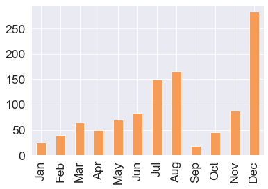

```python
month_day_negative_sorted.plot(kind='bar', color='#f69c56');
# plt.gca().invert_xaxis()
```

https://pandas.pydata.org/docs/reference/api/pandas.cut.html

## Conclusions

- Introduction
- Data Wrangling
- Data Cleaning
- Exploratory Data Analysis
- **Conclusions**

```python
# jupyter nbconvert 2018_Analysis.ipynb --to slides --post serve --template output_toggle
```

```python
# ! --> used to run terminal/ command line expression in jupyter notebook
!jupyter nbconvert 2018_Analysis.ipynb --TagRemovePreprocessor.remove_input_tags='{"remove_cell"}' --to slides -- no-input
```

```
[NbConvertApp] WARNING | Config option `kernel_spec_manager_class` not recognized by `NbConvertApp`.
[NbConvertApp] WARNING | pattern 'no-input' matched no files
[NbConvertApp] Converting notebook 2018_Analysis.ipynb to slides
[NbConvertApp] Writing 1962153 bytes to 2018_Analysis.slides.html
```